# examples_0327

Solve the equation below.
$$7=5
x-8$$

Rewrite the given equation.
$$7=5
x-8$$
Add 8 to both sides of the equation.

$$15=5 x$$

Divide both sides of the equation by 5.

$$3=x$$

Switch sides (which is allowed because equality is commutative).

$$x=3$$

You can check your possible answer by substituting 3 for $x$ in the original equation.

$$7\stackrel{?}{=}5 (3)-8$$

$$7 \stackrel{?}{=} 15-8$$

$$7 \stackrel{\checkmark}{=}
7$$

So, indeed we see that $x=3$ is a solution to the equation.

Solve the equation below.
$$23=7
x+9$$

Rewrite the given equation.
$$23=7
x+9$$
Subtract 9 from both sides of the equation.

$$14=7 x$$

Divide both sides of the equation by 7.

$$2=x$$

Switch sides (which is allowed because equality is commutative).

$$x=2$$

You can check your possible answer by substituting 2 for $x$ in the original equation.

$$23\stackrel{?}{=}7 (2)+9$$

$$23 \stackrel{?}{=} 14+9$$

$$23 \stackrel{\checkmark}{=}
23$$

So, indeed we see that $x=2$ is a solution to the equation.

Solve the equation below.
$$2=\frac{x-3}{4}$$

Rewrite the given equation.
$$2=\frac{x-3}{4}$$
Multiply both sides of the equation by 4.

$$8=x-3$$

Add 3 to both sides of the equation.

$$11=x$$

Switch sides (which is allowed because equality is commutative).

$$x=11$$

You can check your possible answer by substituting 11 for $x$ in the original equation.

$$2\stackrel{?}{=}\frac{(11)-3}{4}$$

$$2 \stackrel{?}{=}
\frac{8}{4}$$

$$2 \stackrel{\checkmark}{=}
2$$

So, indeed we see that $x=11$ is a solution to the equation.

Solve the equation below.
$$2=\frac{x}{3}-2$$

Rewrite the given equation.
$$2=\frac{x}{3}-2$$
Add 2 to both sides of the equation.

$$4=\frac{x}{3}$$

Multiply both sides of the equation by 3.

$$12=x$$

Switch sides (which is allowed because equality is commutative).

$$x=12$$

You can check your possible answer by substituting 12 for $x$ in the original equation.

$$2\stackrel{?}{=}\frac{(12)}{3}-2$$

$$2 \stackrel{?}{=} 4-2$$

$$2 \stackrel{\checkmark}{=}
2$$

So, indeed we see that $x=12$ is a solution to the equation.

Solve the equation below.
$$30=3
x+9$$

Rewrite the given equation.
$$30=3
x+9$$
Subtract 9 from both sides of the equation.

$$21=3 x$$

Divide both sides of the equation by 3.

$$7=x$$

Switch sides (which is allowed because equality is commutative).

$$x=7$$

You can check your possible answer by substituting 7 for $x$ in the original equation.

$$30\stackrel{?}{=}3 (7)+9$$

$$30 \stackrel{?}{=} 21+9$$

$$30 \stackrel{\checkmark}{=}
30$$

So, indeed we see that $x=7$ is a solution to the equation.

Solve the equation below.
$$2=\frac{x+3}{5}$$

Rewrite the given equation.
$$2=\frac{x+3}{5}$$
Multiply both sides of the equation by 5.

$$10=x+3$$

Subtract 3 from both sides of the equation.

$$7=x$$

Switch sides (which is allowed because equality is commutative).

$$x=7$$

You can check your possible answer by substituting 7 for $x$ in the original equation.

$$2\stackrel{?}{=}\frac{(7)+3}{5}$$

$$2 \stackrel{?}{=}
\frac{10}{5}$$

$$2 \stackrel{\checkmark}{=}
2$$

So, indeed we see that $x=7$ is a solution to the equation.

Solve the equation below.
$$22=6
x-8$$

Rewrite the given equation.
$$22=6
x-8$$
Add 8 to both sides of the equation.

$$30=6 x$$

Divide both sides of the equation by 6.

$$5=x$$

Switch sides (which is allowed because equality is commutative).

$$x=5$$

You can check your possible answer by substituting 5 for $x$ in the original equation.

$$22\stackrel{?}{=}6 (5)-8$$

$$22 \stackrel{?}{=} 30-8$$

$$22 \stackrel{\checkmark}{=}
22$$

So, indeed we see that $x=5$ is a solution to the equation.

Solve the equation below.
$$12=8
x-4$$

Rewrite the given equation.
$$12=8
x-4$$
Add 4 to both sides of the equation.

$$16=8 x$$

Divide both sides of the equation by 8.

$$2=x$$

Switch sides (which is allowed because equality is commutative).

$$x=2$$

You can check your possible answer by substituting 2 for $x$ in the original equation.

$$12\stackrel{?}{=}8 (2)-4$$

$$12 \stackrel{?}{=} 16-4$$

$$12 \stackrel{\checkmark}{=}
12$$

So, indeed we see that $x=2$ is a solution to the equation.

Solve the equation below.
$$2=\frac{x}{3}-2$$

Rewrite the given equation.
$$2=\frac{x}{3}-2$$
Add 2 to both sides of the equation.

$$4=\frac{x}{3}$$

Multiply both sides of the equation by 3.

$$12=x$$

Switch sides (which is allowed because equality is commutative).

$$x=12$$

You can check your possible answer by substituting 12 for $x$ in the original equation.

$$2\stackrel{?}{=}\frac{(12)}{3}-2$$

$$2 \stackrel{?}{=} 4-2$$

$$2 \stackrel{\checkmark}{=}
2$$

So, indeed we see that $x=12$ is a solution to the equation.

Solve the equation below.
$$34=6
x-8$$

Rewrite the given equation.
$$34=6
x-8$$
Add 8 to both sides of the equation.

$$42=6 x$$

Divide both sides of the equation by 6.

$$7=x$$

Switch sides (which is allowed because equality is commutative).

$$x=7$$

You can check your possible answer by substituting 7 for $x$ in the original equation.

$$34\stackrel{?}{=}6 (7)-8$$

$$34 \stackrel{?}{=} 42-8$$

$$34 \stackrel{\checkmark}{=}
34$$

So, indeed we see that $x=7$ is a solution to the equation.

The graph of $y=f(x)$ is shown below.

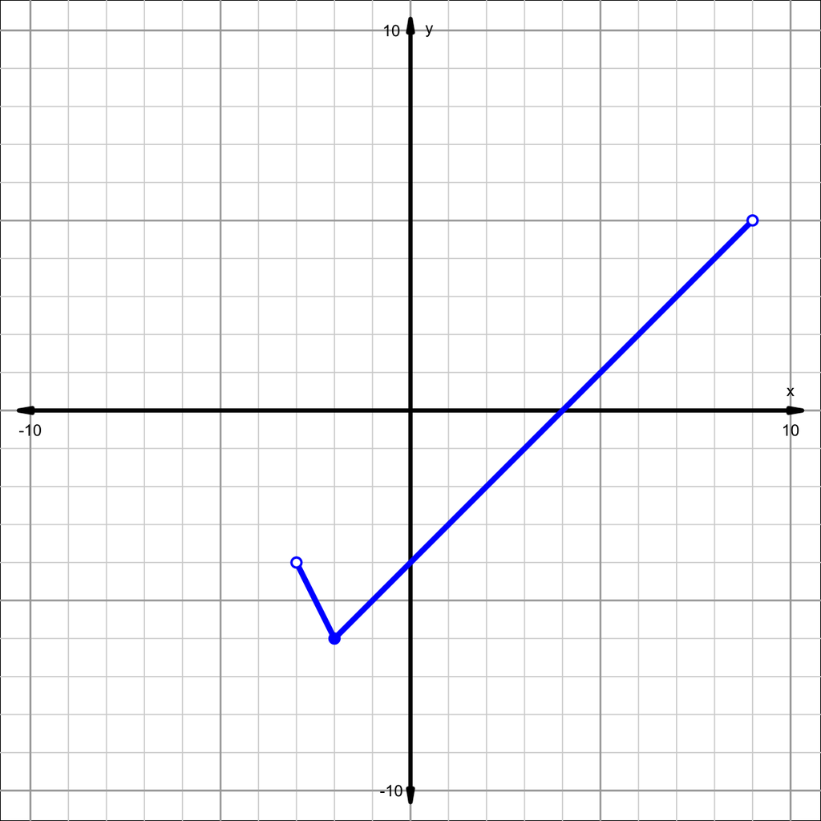

Using interval notation, indicate the intervals described below. All but range indicate $x$ values, and range indicates $y$ values.

1. Where is the function positive?
- (, )
2. Where is the function negative?
- (, )
3. Where is the function increasing?
- (, )
4. Where is the function decreasing?
- (, )
5. What is the domain of the function?
- (, )
6. What is the range of the function?
- [, )
1. Interval where $f$ is positive = (4, 9)
2. Interval where $f$ is negative = (-3, 4)
3. Interval where $f$ is increasing = (-2, 9)
4. Interval where $f$ is decreasing = (-3, -2)
5. Domain = (-3, 9)
6. Range = [-6, 5)

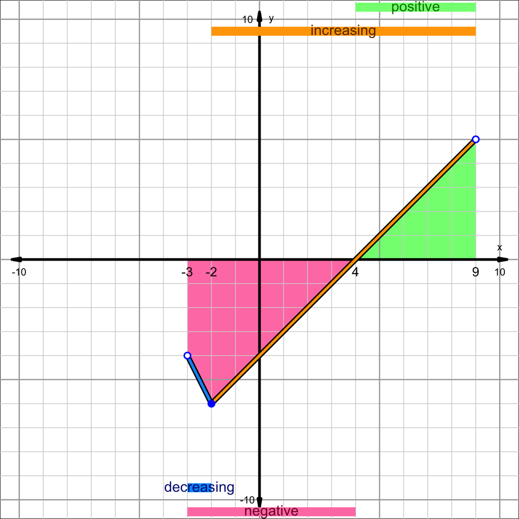

The graph of $y=f(x)$ is shown below.

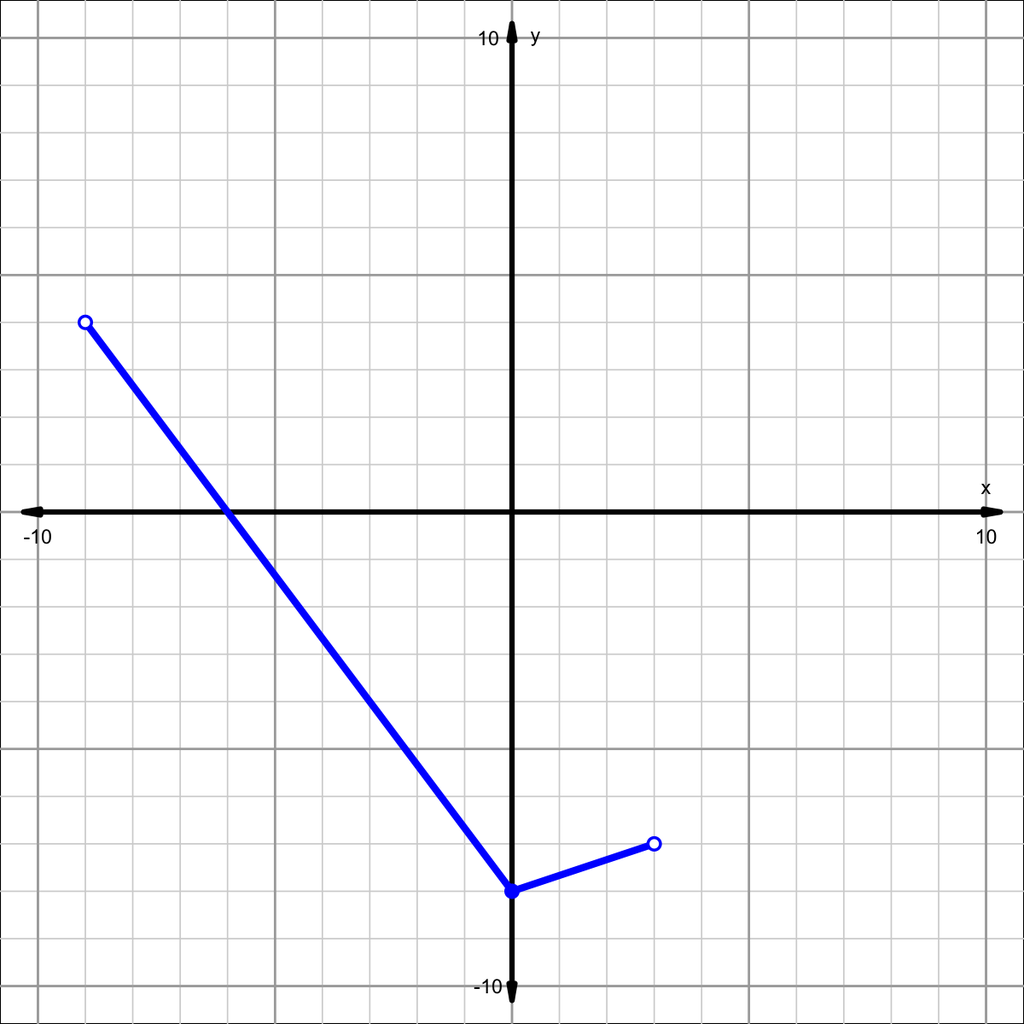

Using interval notation, indicate the intervals described below. All but range indicate $x$ values, and range indicates $y$ values.

1. Where is the function positive?
- (, )
2. Where is the function negative?
- (, )
3. Where is the function increasing?
- (, )
4. Where is the function decreasing?
- (, )
5. What is the domain of the function?
- (, )
6. What is the range of the function?
- [, )
1. Interval where $f$ is positive = (-9, -6)
2. Interval where $f$ is negative = (-6, 3)
3. Interval where $f$ is increasing = (0, 3)
4. Interval where $f$ is decreasing = (-9, 0)
5. Domain = (-9, 3)
6. Range = [-8, 4)

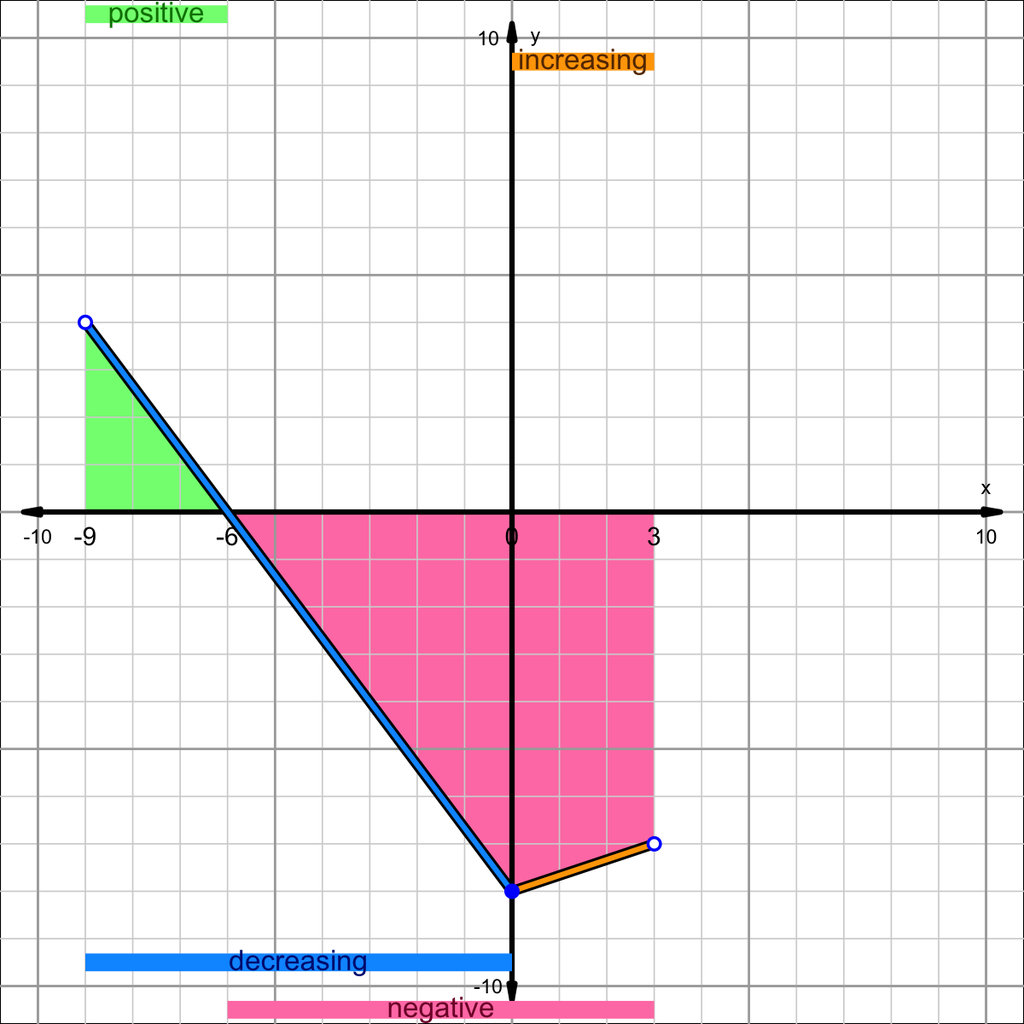

The graph of $y=f(x)$ is shown below.

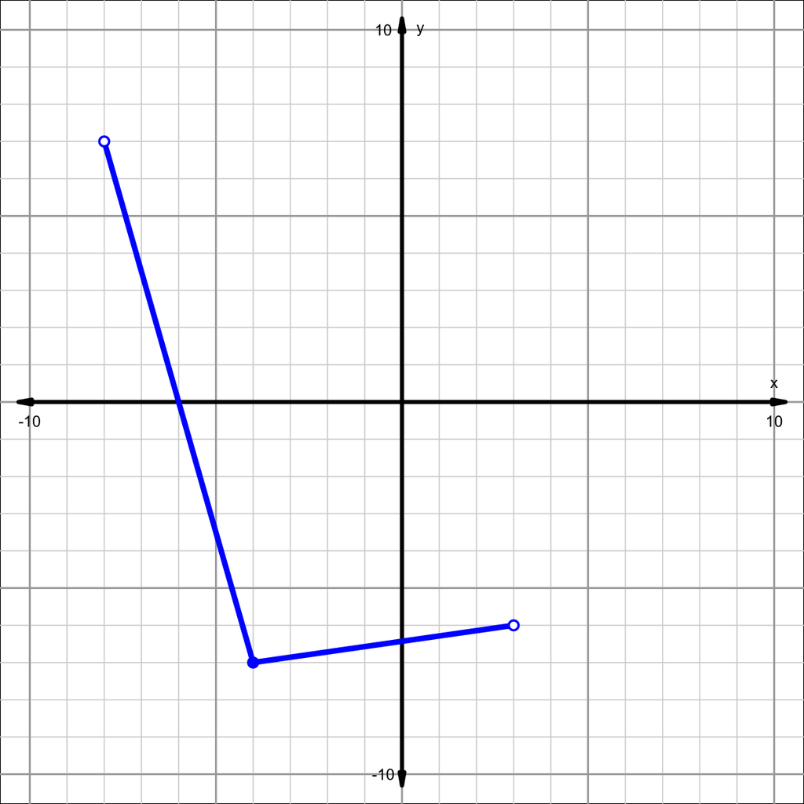

Using interval notation, indicate the intervals described below. All but range indicate $x$ values, and range indicates $y$ values.

1. Where is the function positive?
- (, )
2. Where is the function negative?
- (, )
3. Where is the function increasing?
- (, )
4. Where is the function decreasing?
- (, )
5. What is the domain of the function?
- (, )
6. What is the range of the function?
- [, )
1. Interval where $f$ is positive = (-8, -6)
2. Interval where $f$ is negative = (-6, 3)
3. Interval where $f$ is increasing = (-4, 3)
4. Interval where $f$ is decreasing = (-8, -4)
5. Domain = (-8, 3)
6. Range = [-7, 7)

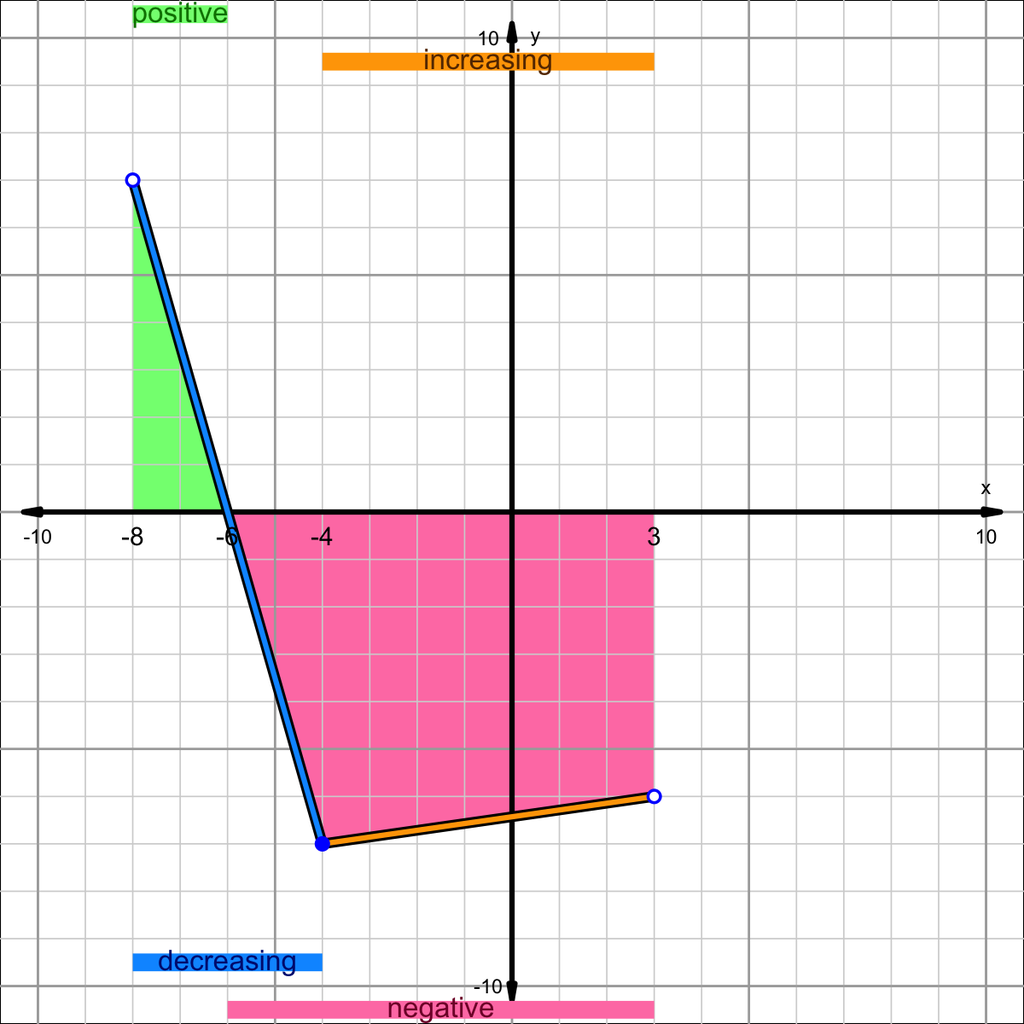

The graph of $y=f(x)$ is shown below.

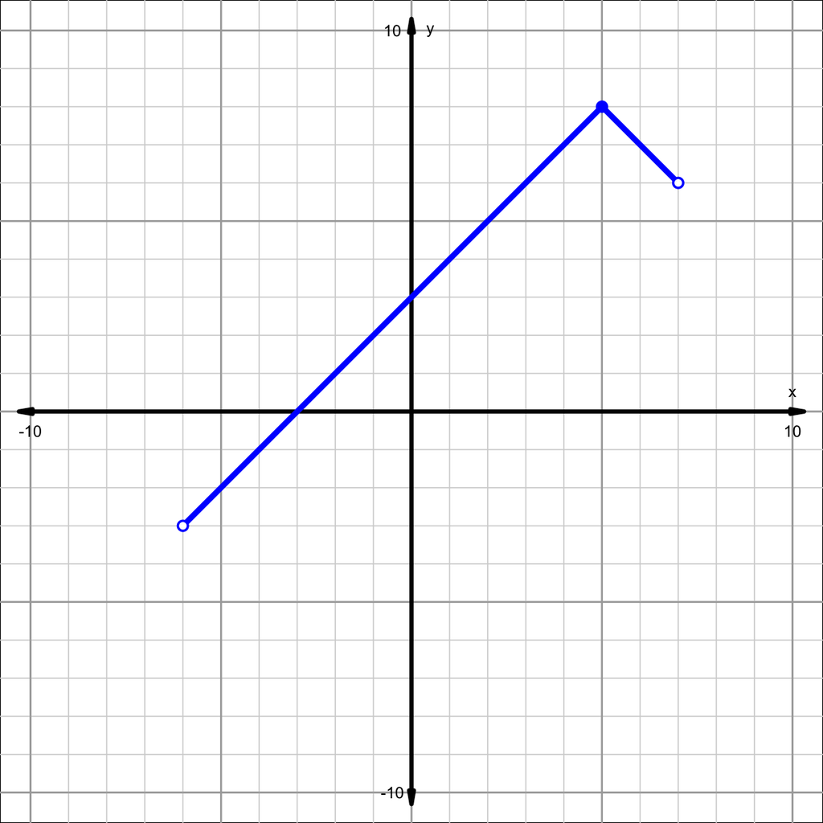

Using interval notation, indicate the intervals described below. All but range indicate $x$ values, and range indicates $y$ values.

1. Where is the function positive?
- (, )
2. Where is the function negative?
- (, )
3. Where is the function increasing?
- (, )
4. Where is the function decreasing?
- (, )
5. What is the domain of the function?
- (, )
6. What is the range of the function?
- (, ]
1. Interval where $f$ is positive = (-3, 7)
2. Interval where $f$ is negative = (-6, -3)
3. Interval where $f$ is increasing = (-6, 5)
4. Interval where $f$ is decreasing = (5, 7)
5. Domain = (-6, 7)
6. Range = (-3, 8]

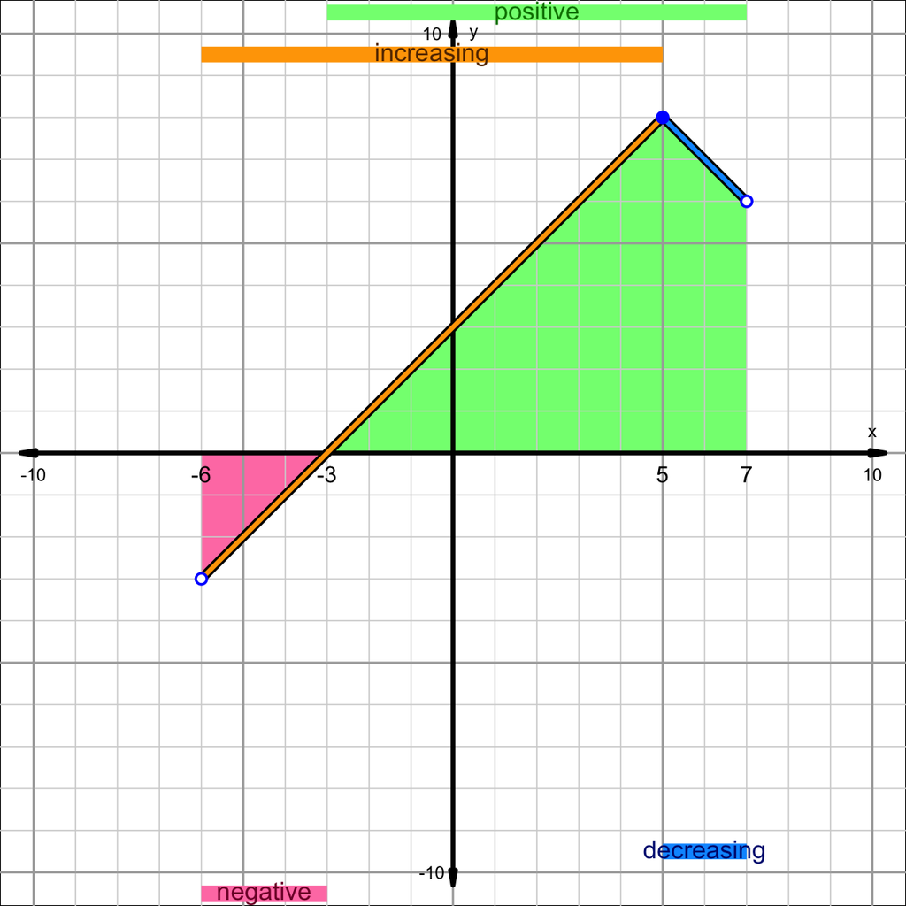

The graph of $y=f(x)$ is shown below.

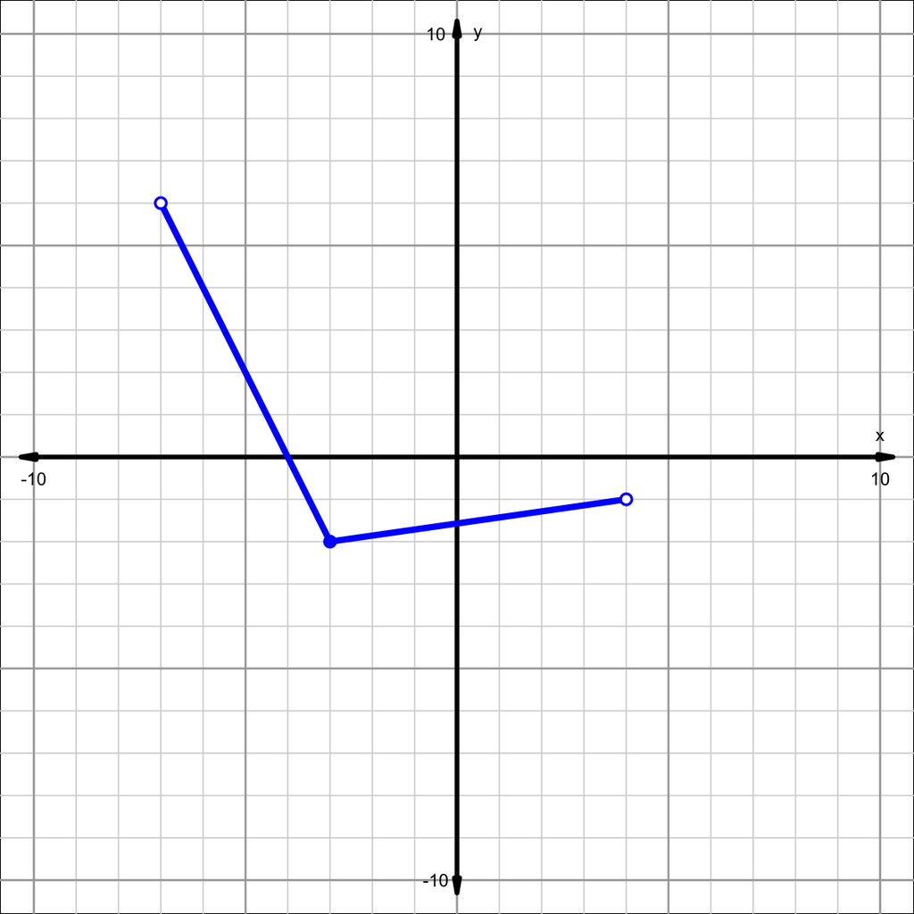

Using interval notation, indicate the intervals described below. All but range indicate $x$ values, and range indicates $y$ values.

1. Where is the function positive?
- (, )
2. Where is the function negative?
- (, )
3. Where is the function increasing?
- (, )
4. Where is the function decreasing?
- (, )
5. What is the domain of the function?
- (, )
6. What is the range of the function?
- [, )
1. Interval where $f$ is positive = (-7, -4)
2. Interval where $f$ is negative = (-4, 4)
3. Interval where $f$ is increasing = (-3, 4)
4. Interval where $f$ is decreasing = (-7, -3)
5. Domain = (-7, 4)
6. Range = [-2, 6)

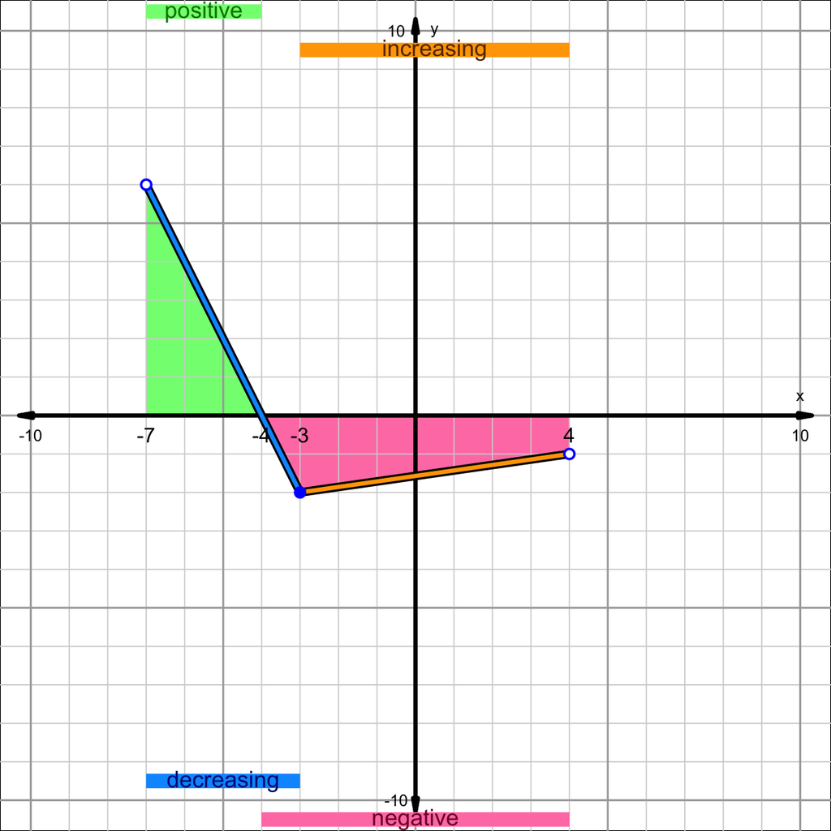

The graph of $y=f(x)$ is shown below.

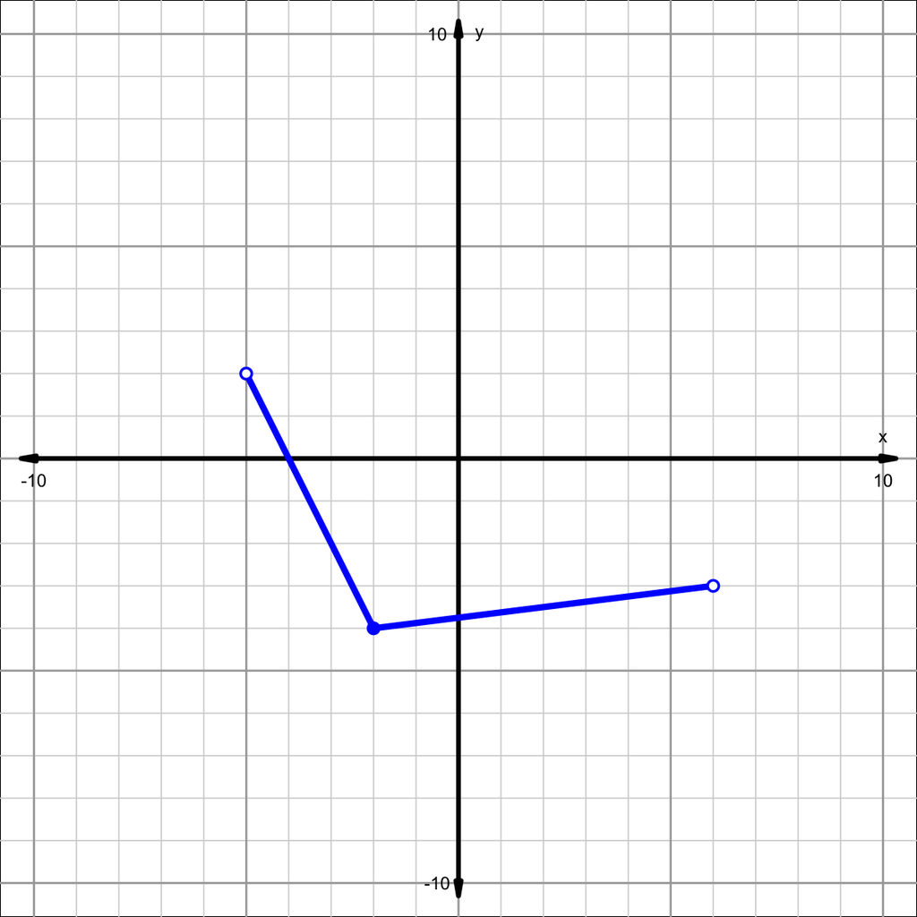

Using interval notation, indicate the intervals described below. All but range indicate $x$ values, and range indicates $y$ values.

1. Where is the function positive?
- (, )
2. Where is the function negative?
- (, )
3. Where is the function increasing?
- (, )
4. Where is the function decreasing?
- (, )
5. What is the domain of the function?
- (, )
6. What is the range of the function?
- [, )
1. Interval where $f$ is positive = (-5, -4)
2. Interval where $f$ is negative = (-4, 6)
3. Interval where $f$ is increasing = (-2, 6)
4. Interval where $f$ is decreasing = (-5, -2)
5. Domain = (-5, 6)
6. Range = [-4, 2)

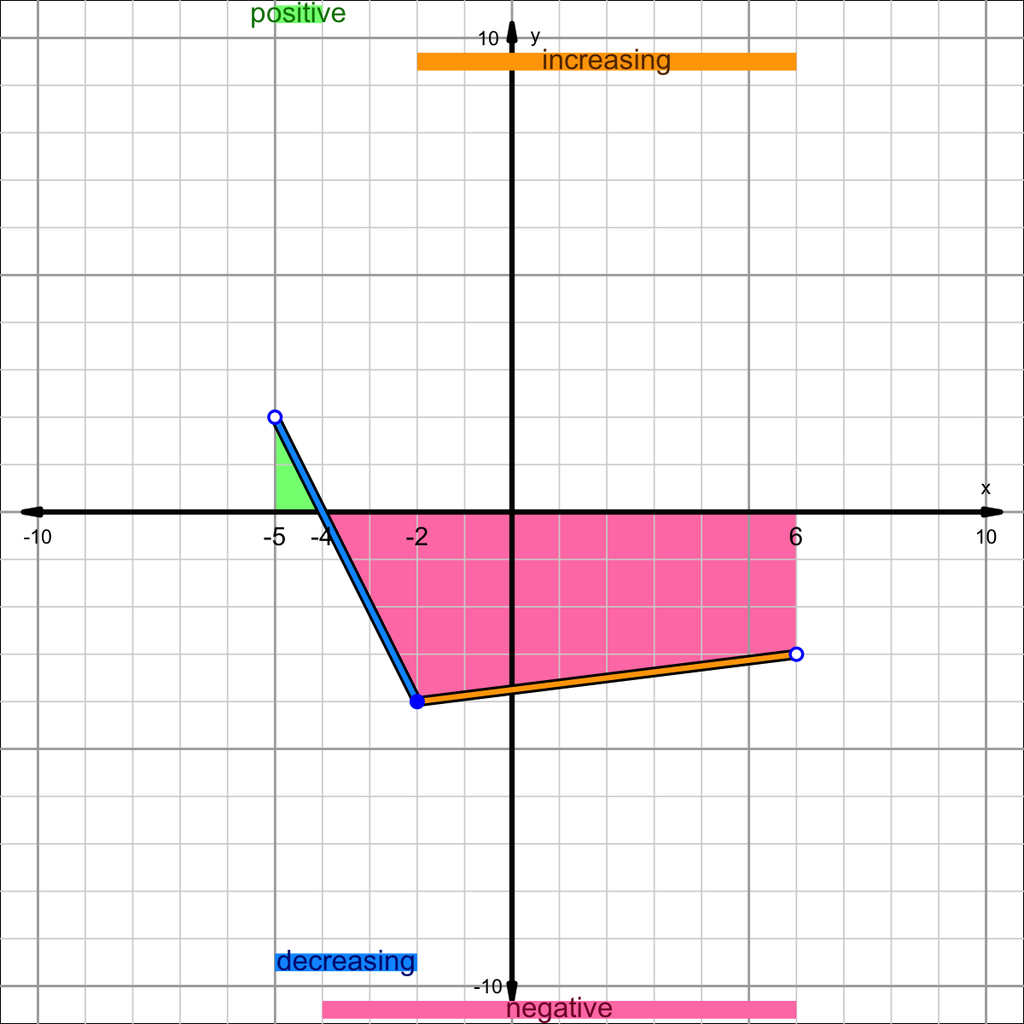

The graph of $y=f(x)$ is shown below.

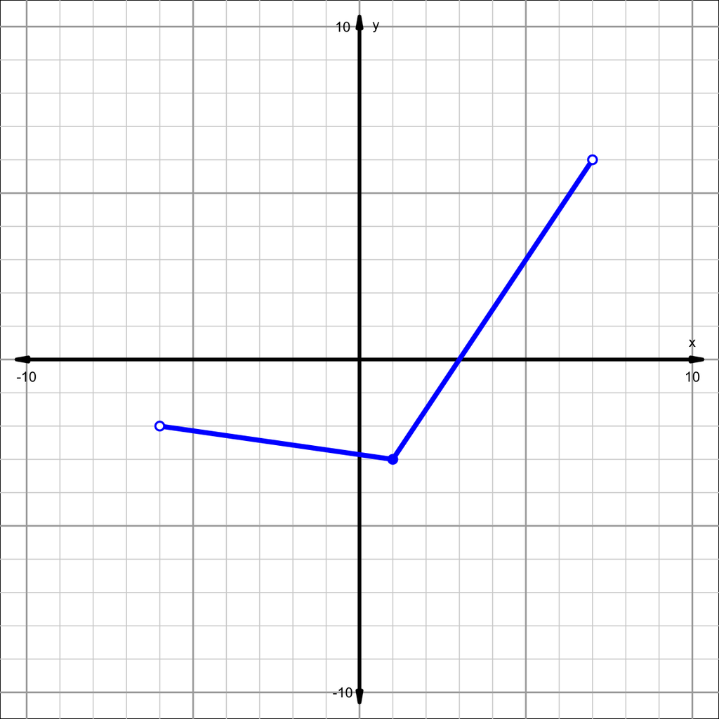

Using interval notation, indicate the intervals described below. All but range indicate $x$ values, and range indicates $y$ values.

1. Where is the function positive?
- (, )
2. Where is the function negative?
- (, )
3. Where is the function increasing?
- (, )
4. Where is the function decreasing?
- (, )
5. What is the domain of the function?
- (, )
6. What is the range of the function?
- [, )
1. Interval where $f$ is positive = (3, 7)
2. Interval where $f$ is negative = (-6, 3)
3. Interval where $f$ is increasing = (1, 7)
4. Interval where $f$ is decreasing = (-6, 1)
5. Domain = (-6, 7)
6. Range = [-3, 6)

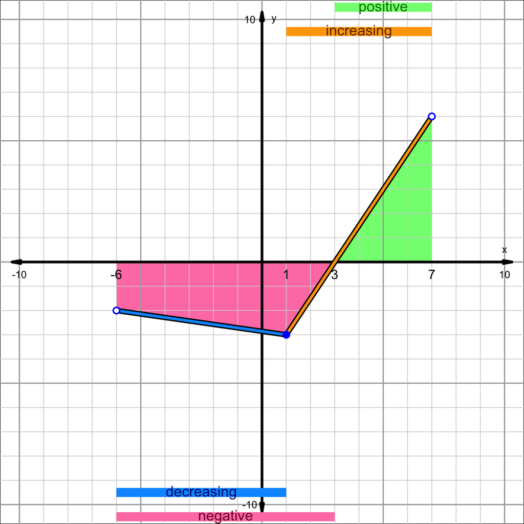

The graph of $y=f(x)$ is shown below.

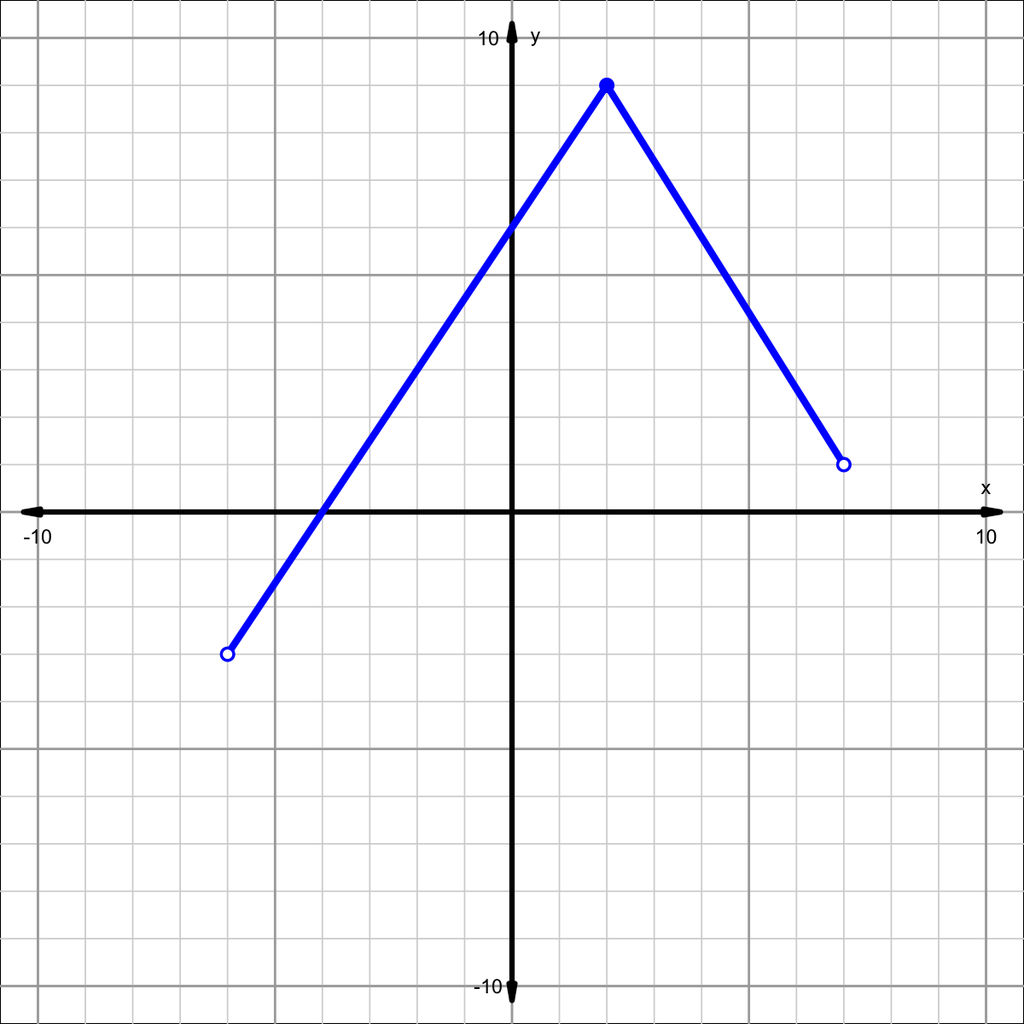

Using interval notation, indicate the intervals described below. All but range indicate $x$ values, and range indicates $y$ values.

1. Where is the function positive?
- (, )
2. Where is the function negative?
- (, )
3. Where is the function increasing?
- (, )
4. Where is the function decreasing?
- (, )
5. What is the domain of the function?
- (, )
6. What is the range of the function?
- (, ]
1. Interval where $f$ is positive = (-4, 7)
2. Interval where $f$ is negative = (-6, -4)
3. Interval where $f$ is increasing = (-6, 2)
4. Interval where $f$ is decreasing = (2, 7)
5. Domain = (-6, 7)
6. Range = (-3, 9]

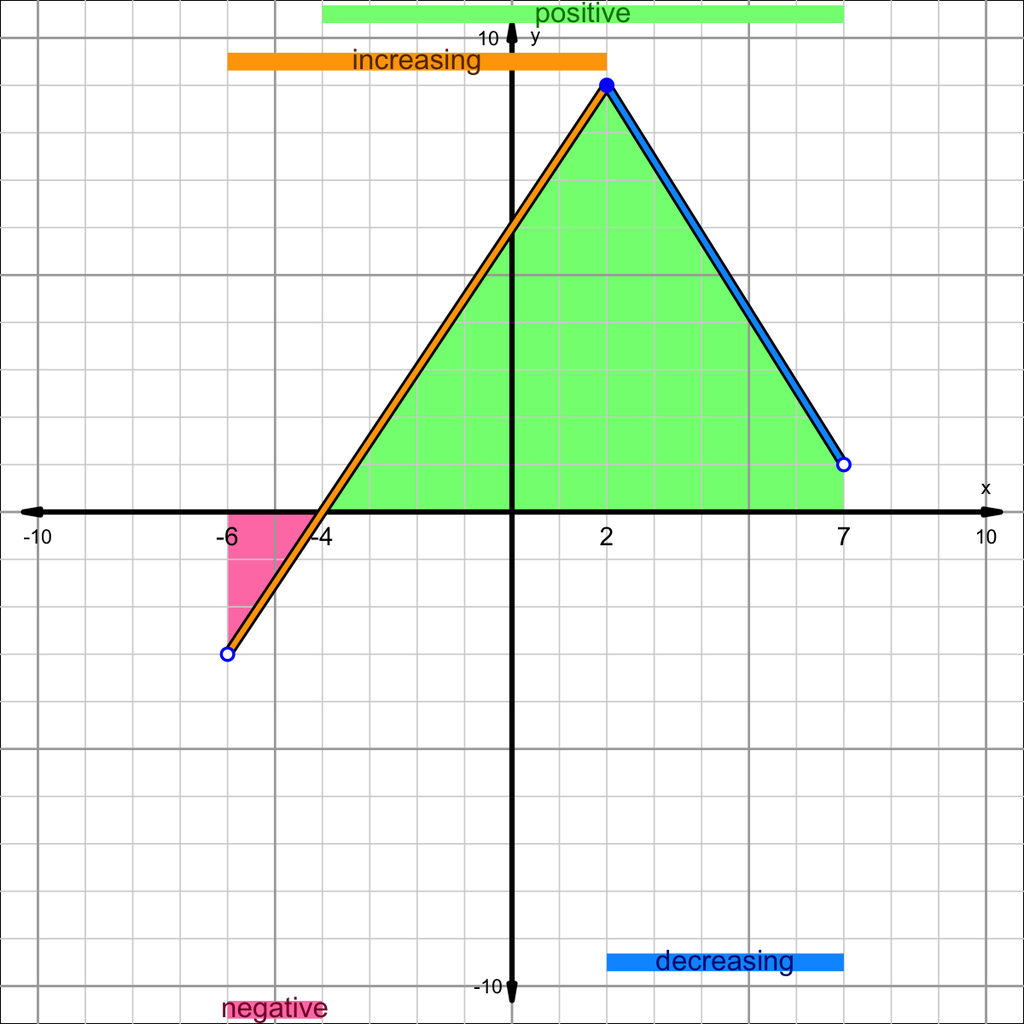

The graph of $y=f(x)$ is shown below.

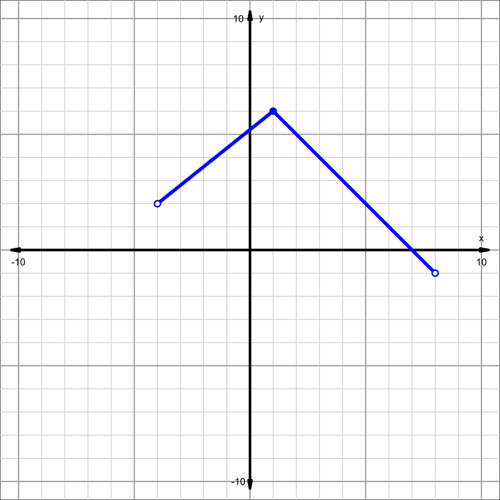

Using interval notation, indicate the intervals described below. All but range indicate $x$ values, and range indicates $y$ values.

1. Where is the function positive?
- (, )
2. Where is the function negative?
- (, )
3. Where is the function increasing?
- (, )
4. Where is the function decreasing?
- (, )
5. What is the domain of the function?
- (, )
6. What is the range of the function?
- (, ]
1. Interval where $f$ is positive = (-4, 7)
2. Interval where $f$ is negative = (7, 8)
3. Interval where $f$ is increasing = (-4, 1)
4. Interval where $f$ is decreasing = (1, 8)
5. Domain = (-4, 8)
6. Range = (-1, 6]

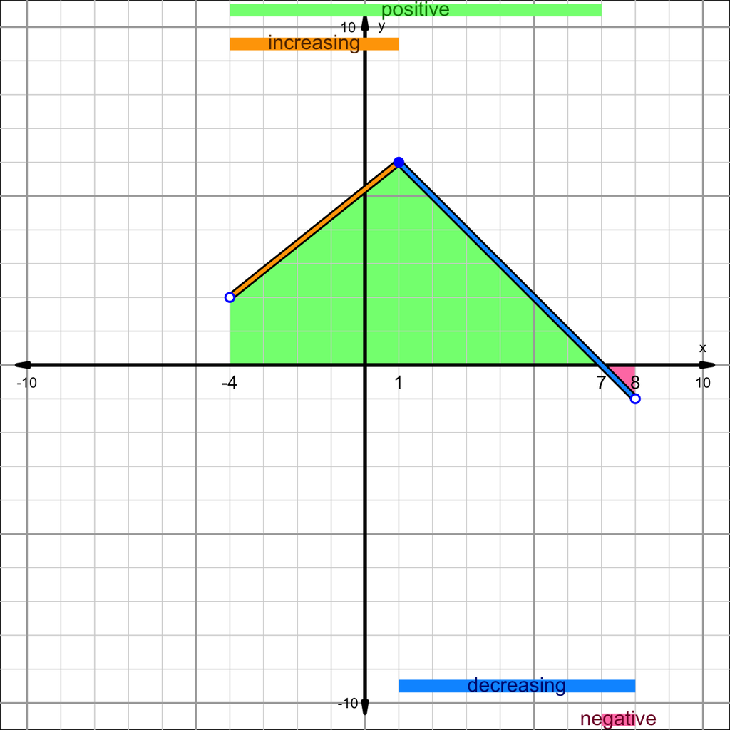

The graph of $y=f(x)$ is shown below.

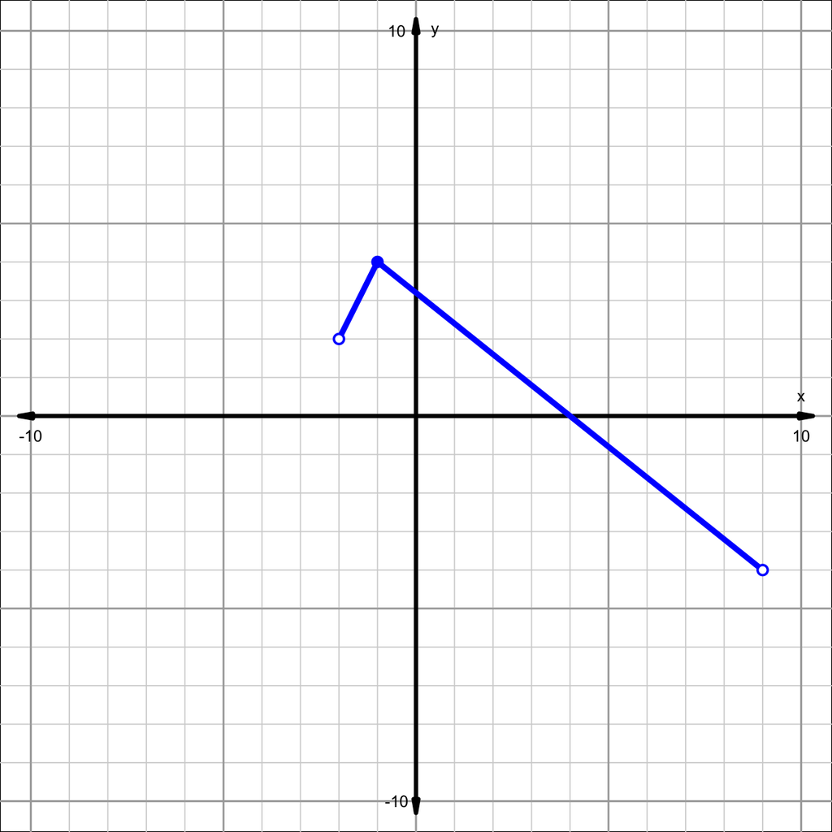

Using interval notation, indicate the intervals described below. All but range indicate $x$ values, and range indicates $y$ values.

1. Where is the function positive?
- (, )
2. Where is the function negative?
- (, )
3. Where is the function increasing?
- (, )
4. Where is the function decreasing?
- (, )
5. What is the domain of the function?
- (, )
6. What is the range of the function?
- (, ]
1. Interval where $f$ is positive = (-2, 4)
2. Interval where $f$ is negative = (4, 9)
3. Interval where $f$ is increasing = (-2, -1)
4. Interval where $f$ is decreasing = (-1, 9)
5. Domain = (-2, 9)
6. Range = (-4, 4]

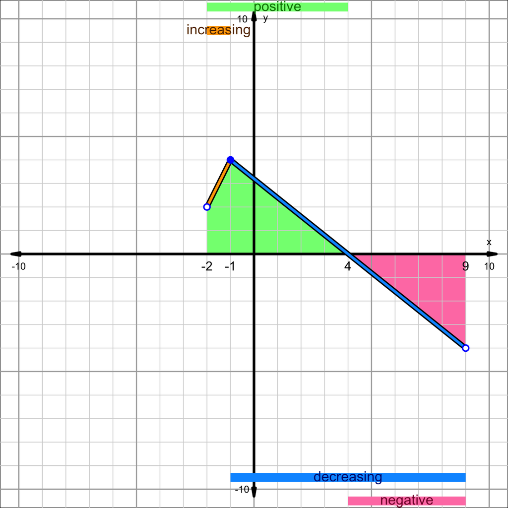

Consider the shifted [square-root function](https://en.wikipedia.org/wiki/Square_root) graphed below:

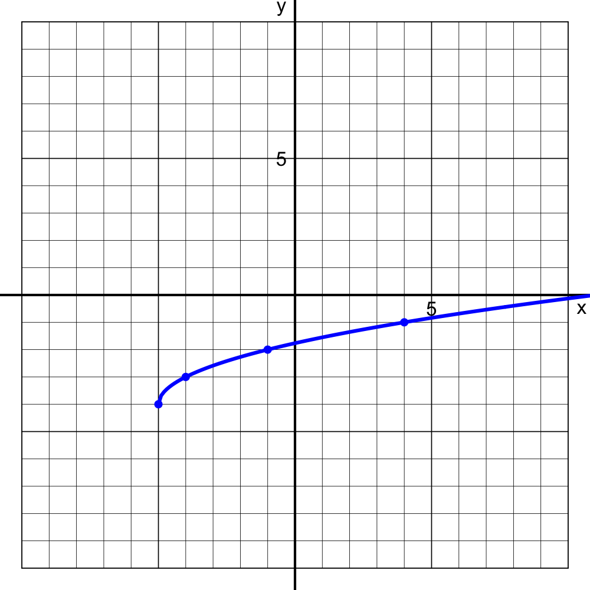

Which equation represents the plotted curve?

$y=\sqrt{x-4}-5$$y=\sqrt{x-4}+5$$y=\sqrt{x-5}-4$$y=\sqrt{x-5}+4$$y=\sqrt{x+4}-5$$y=\sqrt{x+4}+5$$y=\sqrt{x+5}-4$$y=\sqrt{x+5}+4$

The parent function, $y=\sqrt{x}$, has been shifted $5$ units left and $4$ units down.

The correct answer is
$$y=\sqrt{x+5}-4$$

Notice the horizontal translation is counterintuitive. The horizontal coordinate transformation is the INVERSE of the argument expression, whereas the vertical coordinate transformation is simply the outer operations.

$$(a,b)~\to~(a-5,b-4)$$

where $(a,b)$ is a solution to the parent equation $\sqrt{a}=b$. For example, $\sqrt{0}=0$ or $\sqrt{1}=1$ or $\sqrt{4}=2$ or $\sqrt{9}=3$... Thus from curve $y=\sqrt{x}$ to curve $y=\sqrt{x+5}-4$, we have the following coordinate transformations:

$$(0,0) \to (-5,-4)$$
$$(1,1) \to (-4,-3)$$
$$(4,2) \to (-1,-2)$$
$$(9,3) \to (4,-1)$$

Consider the shifted [square-root function](https://en.wikipedia.org/wiki/Square_root) graphed below:

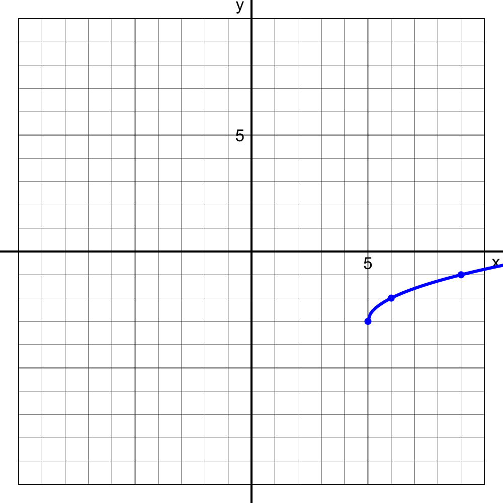

Which equation represents the plotted curve?

$y=\sqrt{x-3}-5$$y=\sqrt{x-3}+5$$y=\sqrt{x-5}-3$$y=\sqrt{x-5}+3$$y=\sqrt{x+3}-5$$y=\sqrt{x+3}+5$$y=\sqrt{x+5}-3$$y=\sqrt{x+5}+3$

The parent function, $y=\sqrt{x}$, has been shifted $5$ units right and $3$ units down.

The correct answer is
$$y=\sqrt{x-5}-3$$

Notice the horizontal translation is counterintuitive. The horizontal coordinate transformation is the INVERSE of the argument expression, whereas the vertical coordinate transformation is simply the outer operations.

$$(a,b)~\to~(a+5,b-3)$$

where $(a,b)$ is a solution to the parent equation $\sqrt{a}=b$. For example, $\sqrt{0}=0$ or $\sqrt{1}=1$ or $\sqrt{4}=2$ or $\sqrt{9}=3$... Thus from curve $y=\sqrt{x}$ to curve $y=\sqrt{x-5}-3$, we have the following coordinate transformations:

$$(0,0) \to (5,-3)$$
$$(1,1) \to (6,-2)$$
$$(4,2) \to (9,-1)$$
$$(9,3) \to (14,0)$$

Consider the shifted [square-root function](https://en.wikipedia.org/wiki/Square_root) graphed below:

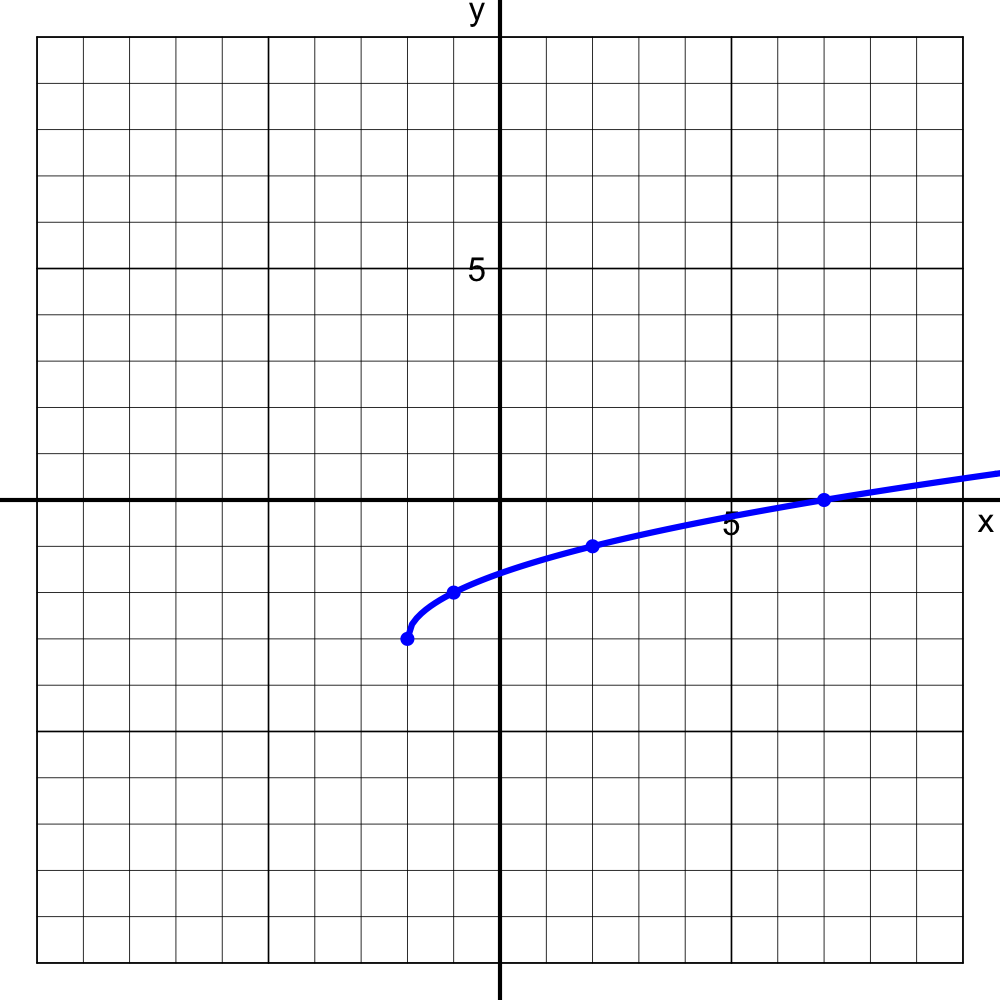

Which equation represents the plotted curve?

$y=\sqrt{x-2}-3$$y=\sqrt{x-2}+3$$y=\sqrt{x-3}-2$$y=\sqrt{x-3}+2$$y=\sqrt{x+2}-3$$y=\sqrt{x+2}+3$$y=\sqrt{x+3}-2$$y=\sqrt{x+3}+2$

The parent function, $y=\sqrt{x}$, has been shifted $2$ units left and $3$ units down.

The correct answer is
$$y=\sqrt{x+2}-3$$

Notice the horizontal translation is counterintuitive. The horizontal coordinate transformation is the INVERSE of the argument expression, whereas the vertical coordinate transformation is simply the outer operations.

$$(a,b)~\to~(a-2,b-3)$$

where $(a,b)$ is a solution to the parent equation $\sqrt{a}=b$. For example, $\sqrt{0}=0$ or $\sqrt{1}=1$ or $\sqrt{4}=2$ or $\sqrt{9}=3$... Thus from curve $y=\sqrt{x}$ to curve $y=\sqrt{x+2}-3$, we have the following coordinate transformations:

$$(0,0) \to (-2,-3)$$
$$(1,1) \to (-1,-2)$$
$$(4,2) \to (2,-1)$$
$$(9,3) \to (7,0)$$

Consider the shifted [square-root function](https://en.wikipedia.org/wiki/Square_root) graphed below:

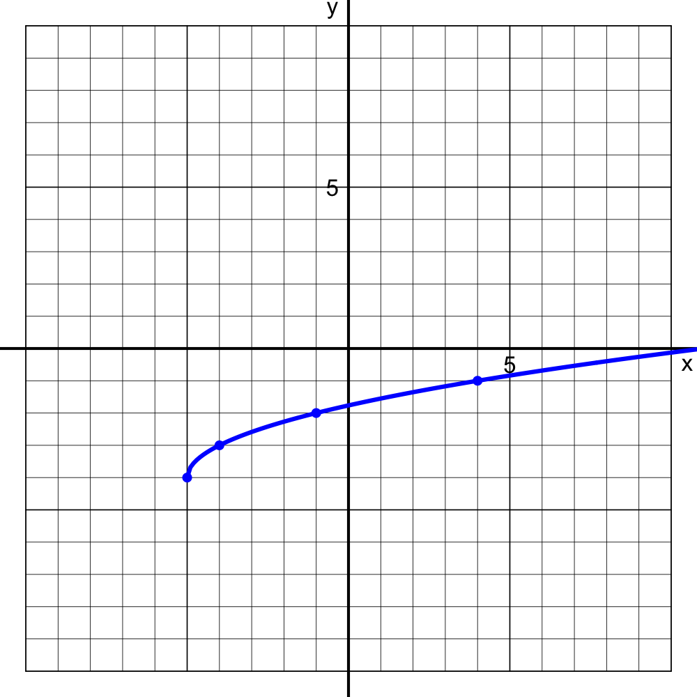

Which equation represents the plotted curve?

$y=\sqrt{x-4}-5$$y=\sqrt{x-4}+5$$y=\sqrt{x-5}-4$$y=\sqrt{x-5}+4$$y=\sqrt{x+4}-5$$y=\sqrt{x+4}+5$$y=\sqrt{x+5}-4$$y=\sqrt{x+5}+4$

The parent function, $y=\sqrt{x}$, has been shifted $5$ units left and $4$ units down.

The correct answer is
$$y=\sqrt{x+5}-4$$

Notice the horizontal translation is counterintuitive. The horizontal coordinate transformation is the INVERSE of the argument expression, whereas the vertical coordinate transformation is simply the outer operations.

$$(a,b)~\to~(a-5,b-4)$$

where $(a,b)$ is a solution to the parent equation $\sqrt{a}=b$. For example, $\sqrt{0}=0$ or $\sqrt{1}=1$ or $\sqrt{4}=2$ or $\sqrt{9}=3$... Thus from curve $y=\sqrt{x}$ to curve $y=\sqrt{x+5}-4$, we have the following coordinate transformations:

$$(0,0) \to (-5,-4)$$
$$(1,1) \to (-4,-3)$$
$$(4,2) \to (-1,-2)$$
$$(9,3) \to (4,-1)$$

Consider the shifted [square-root function](https://en.wikipedia.org/wiki/Square_root) graphed below:

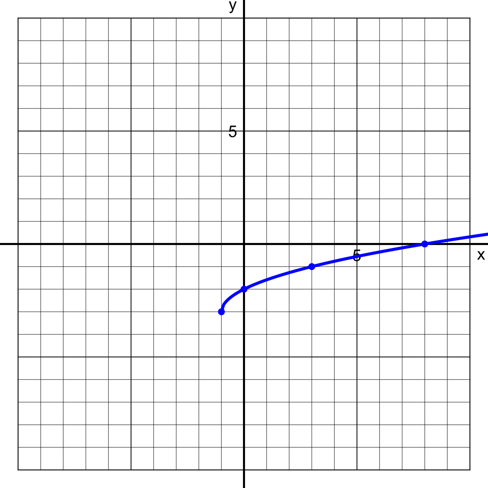

Which equation represents the plotted curve?

$y=\sqrt{x-1}-3$$y=\sqrt{x-1}+3$$y=\sqrt{x-3}-1$$y=\sqrt{x-3}+1$$y=\sqrt{x+1}-3$$y=\sqrt{x+1}+3$$y=\sqrt{x+3}-1$$y=\sqrt{x+3}+1$

The parent function, $y=\sqrt{x}$, has been shifted $1$ units left and $3$ units down.

The correct answer is
$$y=\sqrt{x+1}-3$$

Notice the horizontal translation is counterintuitive. The horizontal coordinate transformation is the INVERSE of the argument expression, whereas the vertical coordinate transformation is simply the outer operations.

$$(a,b)~\to~(a-1,b-3)$$

where $(a,b)$ is a solution to the parent equation $\sqrt{a}=b$. For example, $\sqrt{0}=0$ or $\sqrt{1}=1$ or $\sqrt{4}=2$ or $\sqrt{9}=3$... Thus from curve $y=\sqrt{x}$ to curve $y=\sqrt{x+1}-3$, we have the following coordinate transformations:

$$(0,0) \to (-1,-3)$$
$$(1,1) \to (0,-2)$$
$$(4,2) \to (3,-1)$$
$$(9,3) \to (8,0)$$

Consider the shifted [square-root function](https://en.wikipedia.org/wiki/Square_root) graphed below:

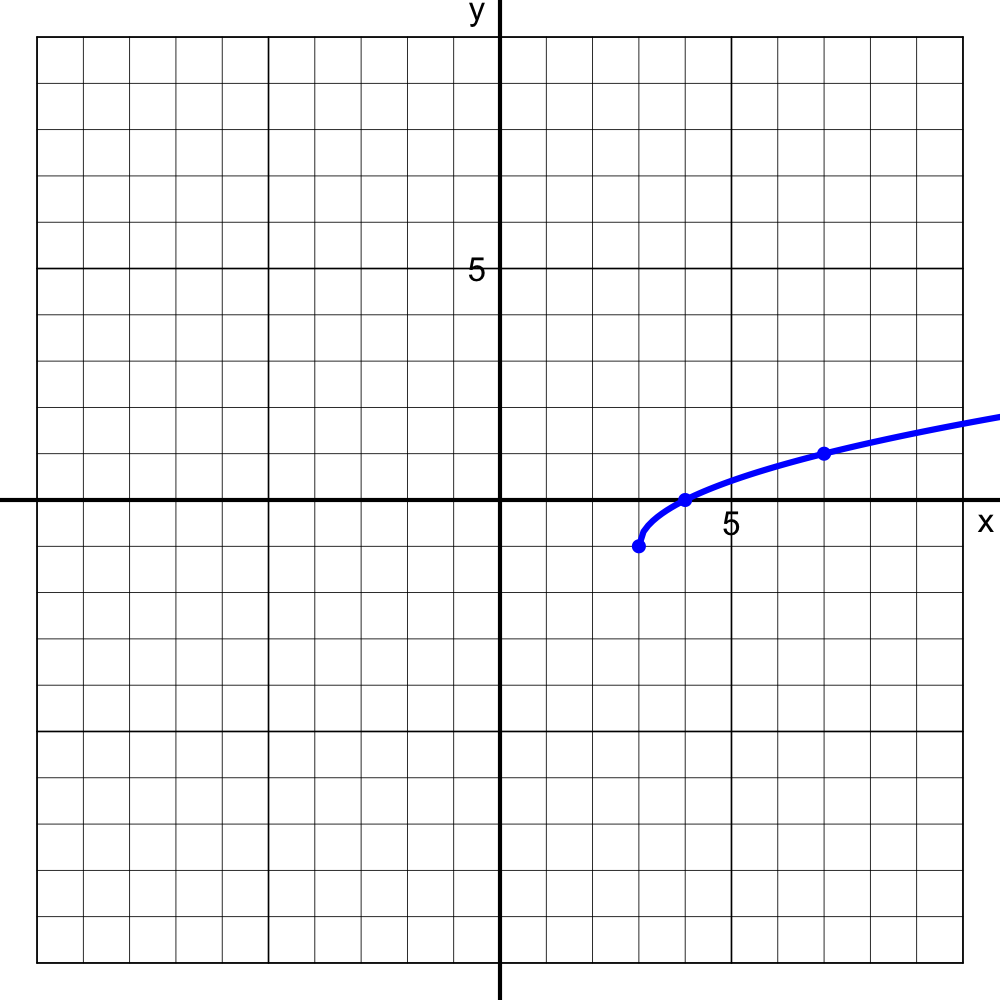

Which equation represents the plotted curve?

$y=\sqrt{x-1}-3$$y=\sqrt{x-1}+3$$y=\sqrt{x-3}-1$$y=\sqrt{x-3}+1$$y=\sqrt{x+1}-3$$y=\sqrt{x+1}+3$$y=\sqrt{x+3}-1$$y=\sqrt{x+3}+1$

The parent function, $y=\sqrt{x}$, has been shifted $3$ units right and $1$ units down.

The correct answer is
$$y=\sqrt{x-3}-1$$

Notice the horizontal translation is counterintuitive. The horizontal coordinate transformation is the INVERSE of the argument expression, whereas the vertical coordinate transformation is simply the outer operations.

$$(a,b)~\to~(a+3,b-1)$$

where $(a,b)$ is a solution to the parent equation $\sqrt{a}=b$. For example, $\sqrt{0}=0$ or $\sqrt{1}=1$ or $\sqrt{4}=2$ or $\sqrt{9}=3$... Thus from curve $y=\sqrt{x}$ to curve $y=\sqrt{x-3}-1$, we have the following coordinate transformations:

$$(0,0) \to (3,-1)$$
$$(1,1) \to (4,0)$$
$$(4,2) \to (7,1)$$
$$(9,3) \to (12,2)$$

Consider the shifted [square-root function](https://en.wikipedia.org/wiki/Square_root) graphed below:

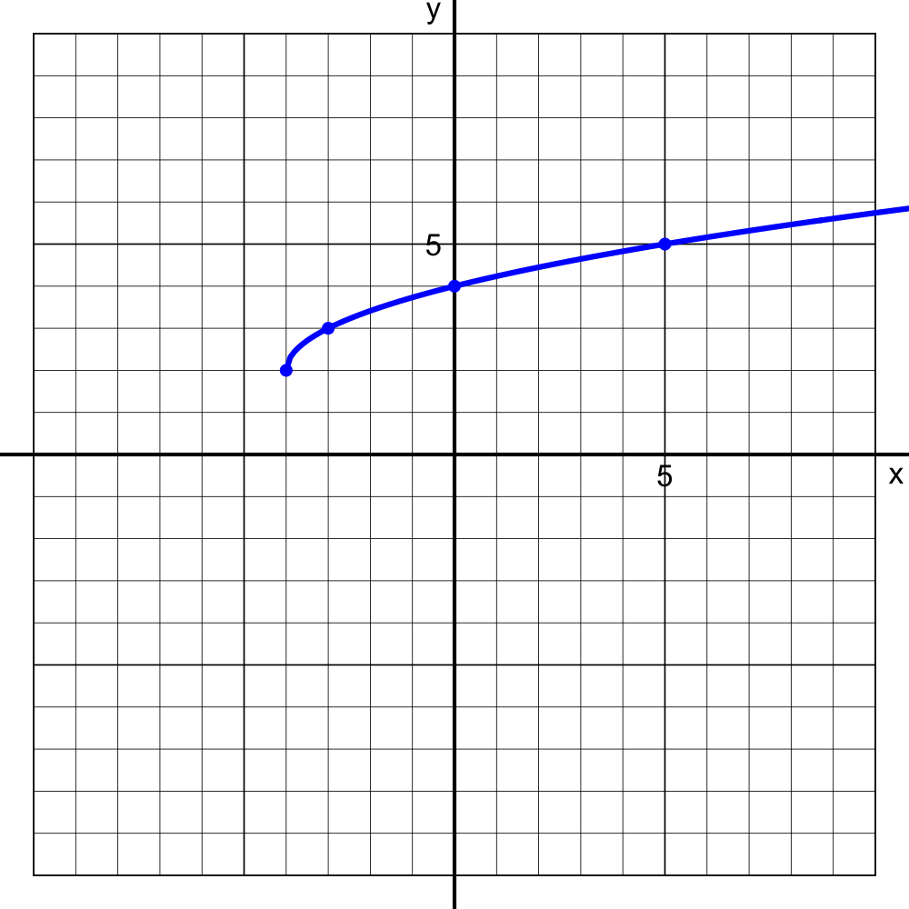

Which equation represents the plotted curve?

$y=\sqrt{x-2}-4$$y=\sqrt{x-2}+4$$y=\sqrt{x-4}-2$$y=\sqrt{x-4}+2$$y=\sqrt{x+2}-4$$y=\sqrt{x+2}+4$$y=\sqrt{x+4}-2$$y=\sqrt{x+4}+2$

The parent function, $y=\sqrt{x}$, has been shifted $4$ units left and $2$ units up.

The correct answer is
$$y=\sqrt{x+4}+2$$

Notice the horizontal translation is counterintuitive. The horizontal coordinate transformation is the INVERSE of the argument expression, whereas the vertical coordinate transformation is simply the outer operations.

$$(a,b)~\to~(a-4,b+2)$$

where $(a,b)$ is a solution to the parent equation $\sqrt{a}=b$. For example, $\sqrt{0}=0$ or $\sqrt{1}=1$ or $\sqrt{4}=2$ or $\sqrt{9}=3$... Thus from curve $y=\sqrt{x}$ to curve $y=\sqrt{x+4}+2$, we have the following coordinate transformations:

$$(0,0) \to (-4,2)$$
$$(1,1) \to (-3,3)$$
$$(4,2) \to (0,4)$$
$$(9,3) \to (5,5)$$

Consider the shifted [square-root function](https://en.wikipedia.org/wiki/Square_root) graphed below:

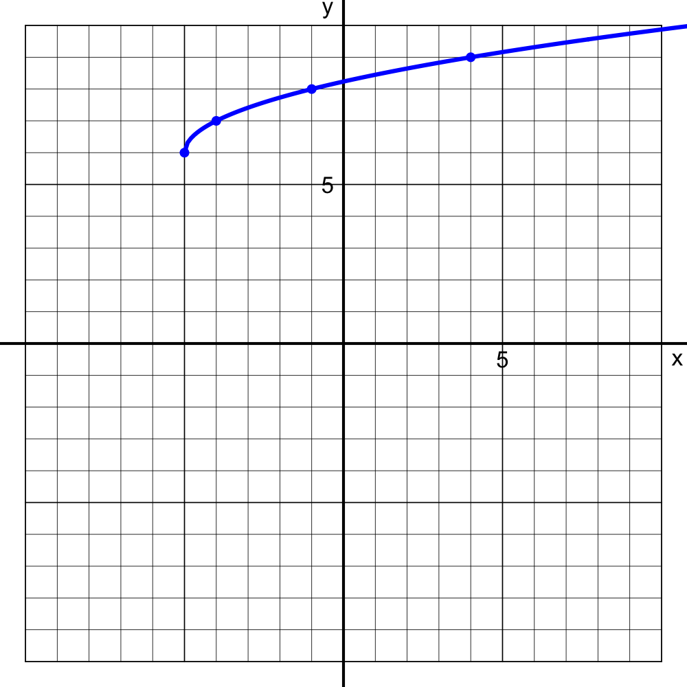

Which equation represents the plotted curve?

$y=\sqrt{x-5}-6$$y=\sqrt{x-5}+6$$y=\sqrt{x-6}-5$$y=\sqrt{x-6}+5$$y=\sqrt{x+5}-6$$y=\sqrt{x+5}+6$$y=\sqrt{x+6}-5$$y=\sqrt{x+6}+5$

The parent function, $y=\sqrt{x}$, has been shifted $5$ units left and $6$ units up.

The correct answer is
$$y=\sqrt{x+5}+6$$

Notice the horizontal translation is counterintuitive. The horizontal coordinate transformation is the INVERSE of the argument expression, whereas the vertical coordinate transformation is simply the outer operations.

$$(a,b)~\to~(a-5,b+6)$$

where $(a,b)$ is a solution to the parent equation $\sqrt{a}=b$. For example, $\sqrt{0}=0$ or $\sqrt{1}=1$ or $\sqrt{4}=2$ or $\sqrt{9}=3$... Thus from curve $y=\sqrt{x}$ to curve $y=\sqrt{x+5}+6$, we have the following coordinate transformations:

$$(0,0) \to (-5,6)$$
$$(1,1) \to (-4,7)$$
$$(4,2) \to (-1,8)$$
$$(9,3) \to (4,9)$$

Consider the shifted [square-root function](https://en.wikipedia.org/wiki/Square_root) graphed below:

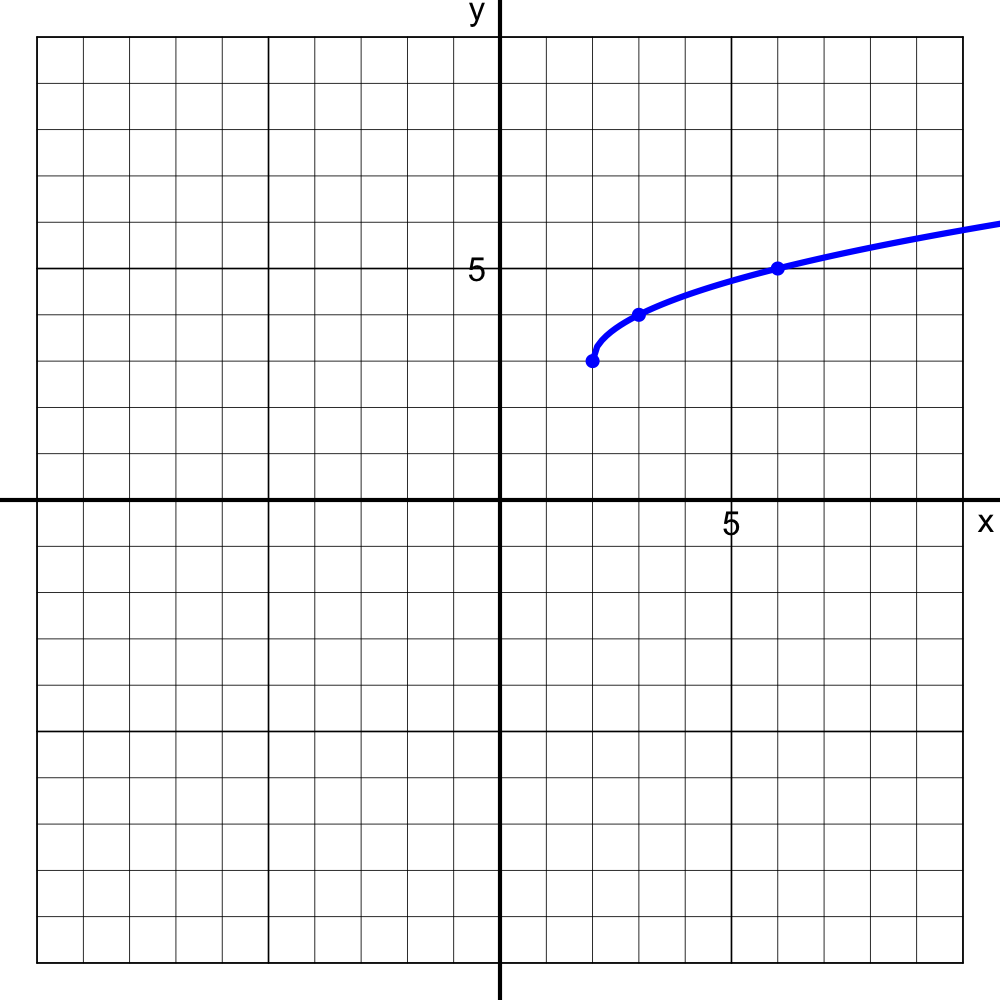

Which equation represents the plotted curve?

$y=\sqrt{x-2}-3$$y=\sqrt{x-2}+3$$y=\sqrt{x-3}-2$$y=\sqrt{x-3}+2$$y=\sqrt{x+2}-3$$y=\sqrt{x+2}+3$$y=\sqrt{x+3}-2$$y=\sqrt{x+3}+2$

The parent function, $y=\sqrt{x}$, has been shifted $2$ units right and $3$ units up.

The correct answer is
$$y=\sqrt{x-2}+3$$

Notice the horizontal translation is counterintuitive. The horizontal coordinate transformation is the INVERSE of the argument expression, whereas the vertical coordinate transformation is simply the outer operations.

$$(a,b)~\to~(a+2,b+3)$$

where $(a,b)$ is a solution to the parent equation $\sqrt{a}=b$. For example, $\sqrt{0}=0$ or $\sqrt{1}=1$ or $\sqrt{4}=2$ or $\sqrt{9}=3$... Thus from curve $y=\sqrt{x}$ to curve $y=\sqrt{x-2}+3$, we have the following coordinate transformations:

$$(0,0) \to (2,3)$$
$$(1,1) \to (3,4)$$
$$(4,2) \to (6,5)$$
$$(9,3) \to (11,6)$$

Consider the shifted [square-root function](https://en.wikipedia.org/wiki/Square_root) graphed below:

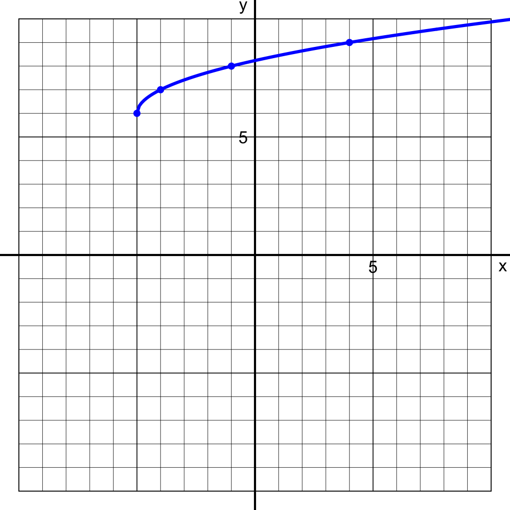

Which equation represents the plotted curve?

$y=\sqrt{x-5}-6$$y=\sqrt{x-5}+6$$y=\sqrt{x-6}-5$$y=\sqrt{x-6}+5$$y=\sqrt{x+5}-6$$y=\sqrt{x+5}+6$$y=\sqrt{x+6}-5$$y=\sqrt{x+6}+5$

The parent function, $y=\sqrt{x}$, has been shifted $5$ units left and $6$ units up.

The correct answer is
$$y=\sqrt{x+5}+6$$

Notice the horizontal translation is counterintuitive. The horizontal coordinate transformation is the INVERSE of the argument expression, whereas the vertical coordinate transformation is simply the outer operations.

$$(a,b)~\to~(a-5,b+6)$$

where $(a,b)$ is a solution to the parent equation $\sqrt{a}=b$. For example, $\sqrt{0}=0$ or $\sqrt{1}=1$ or $\sqrt{4}=2$ or $\sqrt{9}=3$... Thus from curve $y=\sqrt{x}$ to curve $y=\sqrt{x+5}+6$, we have the following coordinate transformations:

$$(0,0) \to (-5,6)$$
$$(1,1) \to (-4,7)$$
$$(4,2) \to (-1,8)$$
$$(9,3) \to (4,9)$$

Calculate the [discriminant](https://en.wikipedia.org/wiki/Quadratic_equation#Discriminant) of the following quadratic function:

$$y~=~{2}x^{2}+{5}x+{14}$$

Identify the coefficients.

$$a=2$$
$$b=5$$
$$c=14$$

Use the formula for the disciminant.

$$D=(5)^2-4(2)(14)$$

$$D=-87$$

The discriminant, $D=-87$, is negative, so there are no $x$-intercepts.

Calculate the [discriminant](https://en.wikipedia.org/wiki/Quadratic_equation#Discriminant) of the following quadratic function:

$$y~=~{-12}x^{2}-{12}x-{3}$$

Identify the coefficients.

$$a=-12$$
$$b=-12$$
$$c=-3$$

Use the formula for the disciminant.

$$D=(-12)^2-4(-12)(-3)$$

$$D=0$$

The discriminant, $D=0$, is zero, so there is one $x$-intercept.

Calculate the [discriminant](https://en.wikipedia.org/wiki/Quadratic_equation#Discriminant) of the following quadratic function:

$$y~=~{12}x^{2}-{16}x+{10}$$

Identify the coefficients.

$$a=12$$
$$b=-16$$
$$c=10$$

Use the formula for the disciminant.

$$D=(-16)^2-4(12)(10)$$

$$D=-224$$

The discriminant, $D=-224$, is negative, so there are no $x$-intercepts.

Calculate the [discriminant](https://en.wikipedia.org/wiki/Quadratic_equation#Discriminant) of the following quadratic function:

$$y~=~{-3}x^{2}+{6}x-{3}$$

Identify the coefficients.

$$a=-3$$
$$b=6$$
$$c=-3$$

Use the formula for the disciminant.

$$D=(6)^2-4(-3)(-3)$$

$$D=0$$

The discriminant, $D=0$, is zero, so there is one $x$-intercept.

Calculate the [discriminant](https://en.wikipedia.org/wiki/Quadratic_equation#Discriminant) of the following quadratic function:

$$y~=~{-12}x^{2}-{12}x-{3}$$

Identify the coefficients.

$$a=-12$$
$$b=-12$$
$$c=-3$$

Use the formula for the disciminant.

$$D=(-12)^2-4(-12)(-3)$$

$$D=0$$

The discriminant, $D=0$, is zero, so there is one $x$-intercept.

Calculate the [discriminant](https://en.wikipedia.org/wiki/Quadratic_equation#Discriminant) of the following quadratic function:

$$y~=~{-5}x^{2}-{10}x-{5}$$

Identify the coefficients.

$$a=-5$$
$$b=-10$$
$$c=-5$$

Use the formula for the disciminant.

$$D=(-10)^2-4(-5)(-5)$$

$$D=0$$

The discriminant, $D=0$, is zero, so there is one $x$-intercept.

Calculate the [discriminant](https://en.wikipedia.org/wiki/Quadratic_equation#Discriminant) of the following quadratic function:

$$y~=~{-8}x^{2}-{8}x-{2}$$

Identify the coefficients.

$$a=-8$$
$$b=-8$$
$$c=-2$$

Use the formula for the disciminant.

$$D=(-8)^2-4(-8)(-2)$$

$$D=0$$

The discriminant, $D=0$, is zero, so there is one $x$-intercept.

Calculate the [discriminant](https://en.wikipedia.org/wiki/Quadratic_equation#Discriminant) of the following quadratic function:

$$y~=~{6}x^{2}-{8}x+{5}$$

Identify the coefficients.

$$a=6$$
$$b=-8$$
$$c=5$$

Use the formula for the disciminant.

$$D=(-8)^2-4(6)(5)$$

$$D=-56$$

The discriminant, $D=-56$, is negative, so there are no $x$-intercepts.

Calculate the [discriminant](https://en.wikipedia.org/wiki/Quadratic_equation#Discriminant) of the following quadratic function:

$$y~=~{-3}x^{2}+{15}x-{15}$$

Identify the coefficients.

$$a=-3$$
$$b=15$$
$$c=-15$$

Use the formula for the disciminant.

$$D=(15)^2-4(-3)(-15)$$

$$D=45$$

The discriminant, $D=45$, is positive, so there are two $x$-intercepts.

Calculate the [discriminant](https://en.wikipedia.org/wiki/Quadratic_equation#Discriminant) of the following quadratic function:

$$y~=~{6}x^{2}+{12}x+{6}$$

Identify the coefficients.

$$a=6$$
$$b=12$$
$$c=6$$

Use the formula for the disciminant.

$$D=(12)^2-4(6)(6)$$

$$D=0$$

The discriminant, $D=0$, is zero, so there is one $x$-intercept.

Find all solutions to the equation below:

$$(x-{5})^2~=~16$$

Notice, because the squaring function is NOT one-to-one, when we "undo" it on both sides of an equation, we need to consider multiple possibilities.

In this case, you should know that, when squared, both $-4$ and $4$ produce $16$.

$$(x-{5})^2~=~16$$

$$x-{5}~=~\pm4$$

$$x~=~5\pm4$$

So the two solutions are $x=9$ and $x=1$.

Find all solutions to the equation below:

$$(x-{9})^2~=~36$$

Notice, because the squaring function is NOT one-to-one, when we "undo" it on both sides of an equation, we need to consider multiple possibilities.

In this case, you should know that, when squared, both $-6$ and $6$ produce $36$.

$$(x-{9})^2~=~36$$

$$x-{9}~=~\pm6$$

$$x~=~9\pm6$$

So the two solutions are $x=15$ and $x=3$.

Find all solutions to the equation below:

$$(x+{4})^2~=~64$$

Notice, because the squaring function is NOT one-to-one, when we "undo" it on both sides of an equation, we need to consider multiple possibilities.

In this case, you should know that, when squared, both $-8$ and $8$ produce $64$.

$$(x+{4})^2~=~64$$

$$x+{4}~=~\pm8$$

$$x~=~-4\pm8$$

So the two solutions are $x=4$ and $x=-12$.

Find all solutions to the equation below:

$$(x+{6})^2~=~100$$

Notice, because the squaring function is NOT one-to-one, when we "undo" it on both sides of an equation, we need to consider multiple possibilities.

In this case, you should know that, when squared, both $-10$ and $10$ produce $100$.

$$(x+{6})^2~=~100$$

$$x+{6}~=~\pm10$$

$$x~=~-6\pm10$$

So the two solutions are $x=4$ and $x=-16$.

Find all solutions to the equation below:

$$(x-{6})^2~=~16$$

Notice, because the squaring function is NOT one-to-one, when we "undo" it on both sides of an equation, we need to consider multiple possibilities.

In this case, you should know that, when squared, both $-4$ and $4$ produce $16$.

$$(x-{6})^2~=~16$$

$$x-{6}~=~\pm4$$

$$x~=~6\pm4$$

So the two solutions are $x=10$ and $x=2$.

Find all solutions to the equation below:

$$(x-{5})^2~=~81$$

Notice, because the squaring function is NOT one-to-one, when we "undo" it on both sides of an equation, we need to consider multiple possibilities.

In this case, you should know that, when squared, both $-9$ and $9$ produce $81$.

$$(x-{5})^2~=~81$$

$$x-{5}~=~\pm9$$

$$x~=~5\pm9$$

So the two solutions are $x=14$ and $x=-4$.

Find all solutions to the equation below:

$$(x+{7})^2~=~81$$

Notice, because the squaring function is NOT one-to-one, when we "undo" it on both sides of an equation, we need to consider multiple possibilities.

In this case, you should know that, when squared, both $-9$ and $9$ produce $81$.

$$(x+{7})^2~=~81$$

$$x+{7}~=~\pm9$$

$$x~=~-7\pm9$$

So the two solutions are $x=2$ and $x=-16$.

Find all solutions to the equation below:

$$(x-{5})^2~=~49$$

Notice, because the squaring function is NOT one-to-one, when we "undo" it on both sides of an equation, we need to consider multiple possibilities.

In this case, you should know that, when squared, both $-7$ and $7$ produce $49$.

$$(x-{5})^2~=~49$$

$$x-{5}~=~\pm7$$

$$x~=~5\pm7$$

So the two solutions are $x=12$ and $x=-2$.

Find all solutions to the equation below:

$$(x+{9})^2~=~64$$

Notice, because the squaring function is NOT one-to-one, when we "undo" it on both sides of an equation, we need to consider multiple possibilities.

In this case, you should know that, when squared, both $-8$ and $8$ produce $64$.

$$(x+{9})^2~=~64$$

$$x+{9}~=~\pm8$$

$$x~=~-9\pm8$$

So the two solutions are $x=-1$ and $x=-17$.

Find all solutions to the equation below:

$$(x+{4})^2~=~49$$

Notice, because the squaring function is NOT one-to-one, when we "undo" it on both sides of an equation, we need to consider multiple possibilities.

In this case, you should know that, when squared, both $-7$ and $7$ produce $49$.

$$(x+{4})^2~=~49$$

$$x+{4}~=~\pm7$$

$$x~=~-4\pm7$$

So the two solutions are $x=3$ and $x=-11$.

Simplify the following powers of $i$.

- $i^{55}=$
- $i^{56}=$
- $i^{69}=$
- $i^{74}=$
- $i^{78}=$

For any positive integer $n$, we can evaluate $i^n$ by determining the remainder when $n$ is divided by 4.

| Remainder of $n/4$ | $i^n$ |
| --- | --- |
| 0 | $1$ |
| 1 | $i$ |
| 2 | $-1$ |
| 3 | $-i$ |

In computer programming, the [modulo operator](https://en.wikipedia.org/wiki/Modulo) returns the remainder. This operation is used so frequently, that it is often abbreviated to a single symbol (for example, in Python, `5%2` represents the remainder when 5 is divided by 2.)

I will represent the remainders using the [Desmos](https://www.desmos.com/calculator) notation.

- $\mathrm{mod}(55,4)=3$ so $i^{55}=-i$
- $\mathrm{mod}(56,4)=0$ so $i^{56}=1$
- $\mathrm{mod}(69,4)=1$ so $i^{69}=i$
- $\mathrm{mod}(74,4)=2$ so $i^{74}=-1$
- $\mathrm{mod}(78,4)=2$ so $i^{78}=-1$

To find the remainder using a scientific calculator, I would divide by 4, [floor](https://en.wikipedia.org/wiki/Floor_and_ceiling_functions) the result, multiply by 4, and subtract that amount from the original.

$$\mathrm{mod}(x,4)~=~x-4\cdot
\left\lfloor\frac{x}{4}\right\rfloor$$

Simplify the following powers of $i$.

- $i^{62}=$
- $i^{65}=$
- $i^{76}=$
- $i^{86}=$
- $i^{87}=$

For any positive integer $n$, we can evaluate $i^n$ by determining the remainder when $n$ is divided by 4.

| Remainder of $n/4$ | $i^n$ |
| --- | --- |
| 0 | $1$ |
| 1 | $i$ |
| 2 | $-1$ |
| 3 | $-i$ |

In computer programming, the [modulo operator](https://en.wikipedia.org/wiki/Modulo) returns the remainder. This operation is used so frequently, that it is often abbreviated to a single symbol (for example, in Python, `5%2` represents the remainder when 5 is divided by 2.)

I will represent the remainders using the [Desmos](https://www.desmos.com/calculator) notation.

- $\mathrm{mod}(62,4)=2$ so $i^{62}=-1$
- $\mathrm{mod}(65,4)=1$ so $i^{65}=i$
- $\mathrm{mod}(76,4)=0$ so $i^{76}=1$
- $\mathrm{mod}(86,4)=2$ so $i^{86}=-1$
- $\mathrm{mod}(87,4)=3$ so $i^{87}=-i$

To find the remainder using a scientific calculator, I would divide by 4, [floor](https://en.wikipedia.org/wiki/Floor_and_ceiling_functions) the result, multiply by 4, and subtract that amount from the original.

$$\mathrm{mod}(x,4)~=~x-4\cdot
\left\lfloor\frac{x}{4}\right\rfloor$$

Simplify the following powers of $i$.

- $i^{18}=$
- $i^{55}=$
- $i^{68}=$
- $i^{69}=$
- $i^{89}=$

For any positive integer $n$, we can evaluate $i^n$ by determining the remainder when $n$ is divided by 4.

| Remainder of $n/4$ | $i^n$ |
| --- | --- |
| 0 | $1$ |
| 1 | $i$ |
| 2 | $-1$ |
| 3 | $-i$ |

In computer programming, the [modulo operator](https://en.wikipedia.org/wiki/Modulo) returns the remainder. This operation is used so frequently, that it is often abbreviated to a single symbol (for example, in Python, `5%2` represents the remainder when 5 is divided by 2.)

I will represent the remainders using the [Desmos](https://www.desmos.com/calculator) notation.

- $\mathrm{mod}(18,4)=2$ so $i^{18}=-1$
- $\mathrm{mod}(55,4)=3$ so $i^{55}=-i$
- $\mathrm{mod}(68,4)=0$ so $i^{68}=1$
- $\mathrm{mod}(69,4)=1$ so $i^{69}=i$
- $\mathrm{mod}(89,4)=1$ so $i^{89}=i$

To find the remainder using a scientific calculator, I would divide by 4, [floor](https://en.wikipedia.org/wiki/Floor_and_ceiling_functions) the result, multiply by 4, and subtract that amount from the original.

$$\mathrm{mod}(x,4)~=~x-4\cdot
\left\lfloor\frac{x}{4}\right\rfloor$$

Simplify the following powers of $i$.

- $i^{19}=$
- $i^{23}=$
- $i^{30}=$
- $i^{68}=$
- $i^{77}=$

For any positive integer $n$, we can evaluate $i^n$ by determining the remainder when $n$ is divided by 4.

| Remainder of $n/4$ | $i^n$ |
| --- | --- |
| 0 | $1$ |
| 1 | $i$ |
| 2 | $-1$ |
| 3 | $-i$ |

In computer programming, the [modulo operator](https://en.wikipedia.org/wiki/Modulo) returns the remainder. This operation is used so frequently, that it is often abbreviated to a single symbol (for example, in Python, `5%2` represents the remainder when 5 is divided by 2.)

I will represent the remainders using the [Desmos](https://www.desmos.com/calculator) notation.

- $\mathrm{mod}(19,4)=3$ so $i^{19}=-i$
- $\mathrm{mod}(23,4)=3$ so $i^{23}=-i$
- $\mathrm{mod}(30,4)=2$ so $i^{30}=-1$
- $\mathrm{mod}(68,4)=0$ so $i^{68}=1$
- $\mathrm{mod}(77,4)=1$ so $i^{77}=i$

To find the remainder using a scientific calculator, I would divide by 4, [floor](https://en.wikipedia.org/wiki/Floor_and_ceiling_functions) the result, multiply by 4, and subtract that amount from the original.

$$\mathrm{mod}(x,4)~=~x-4\cdot
\left\lfloor\frac{x}{4}\right\rfloor$$

Simplify the following powers of $i$.

- $i^{32}=$
- $i^{51}=$
- $i^{53}=$
- $i^{66}=$
- $i^{88}=$

For any positive integer $n$, we can evaluate $i^n$ by determining the remainder when $n$ is divided by 4.

| Remainder of $n/4$ | $i^n$ |
| --- | --- |
| 0 | $1$ |
| 1 | $i$ |
| 2 | $-1$ |
| 3 | $-i$ |

In computer programming, the [modulo operator](https://en.wikipedia.org/wiki/Modulo) returns the remainder. This operation is used so frequently, that it is often abbreviated to a single symbol (for example, in Python, `5%2` represents the remainder when 5 is divided by 2.)

I will represent the remainders using the [Desmos](https://www.desmos.com/calculator) notation.

- $\mathrm{mod}(32,4)=0$ so $i^{32}=1$
- $\mathrm{mod}(51,4)=3$ so $i^{51}=-i$
- $\mathrm{mod}(53,4)=1$ so $i^{53}=i$
- $\mathrm{mod}(66,4)=2$ so $i^{66}=-1$
- $\mathrm{mod}(88,4)=0$ so $i^{88}=1$

To find the remainder using a scientific calculator, I would divide by 4, [floor](https://en.wikipedia.org/wiki/Floor_and_ceiling_functions) the result, multiply by 4, and subtract that amount from the original.

$$\mathrm{mod}(x,4)~=~x-4\cdot
\left\lfloor\frac{x}{4}\right\rfloor$$

Simplify the following powers of $i$.

- $i^{31}=$
- $i^{57}=$
- $i^{60}=$
- $i^{78}=$
- $i^{86}=$

For any positive integer $n$, we can evaluate $i^n$ by determining the remainder when $n$ is divided by 4.

| Remainder of $n/4$ | $i^n$ |
| --- | --- |
| 0 | $1$ |
| 1 | $i$ |
| 2 | $-1$ |
| 3 | $-i$ |

In computer programming, the [modulo operator](https://en.wikipedia.org/wiki/Modulo) returns the remainder. This operation is used so frequently, that it is often abbreviated to a single symbol (for example, in Python, `5%2` represents the remainder when 5 is divided by 2.)

I will represent the remainders using the [Desmos](https://www.desmos.com/calculator) notation.

- $\mathrm{mod}(31,4)=3$ so $i^{31}=-i$
- $\mathrm{mod}(57,4)=1$ so $i^{57}=i$
- $\mathrm{mod}(60,4)=0$ so $i^{60}=1$
- $\mathrm{mod}(78,4)=2$ so $i^{78}=-1$
- $\mathrm{mod}(86,4)=2$ so $i^{86}=-1$

To find the remainder using a scientific calculator, I would divide by 4, [floor](https://en.wikipedia.org/wiki/Floor_and_ceiling_functions) the result, multiply by 4, and subtract that amount from the original.

$$\mathrm{mod}(x,4)~=~x-4\cdot
\left\lfloor\frac{x}{4}\right\rfloor$$

Simplify the following powers of $i$.

- $i^{51}=$
- $i^{68}=$
- $i^{69}=$
- $i^{74}=$
- $i^{83}=$

For any positive integer $n$, we can evaluate $i^n$ by determining the remainder when $n$ is divided by 4.

| Remainder of $n/4$ | $i^n$ |
| --- | --- |
| 0 | $1$ |
| 1 | $i$ |
| 2 | $-1$ |
| 3 | $-i$ |

In computer programming, the [modulo operator](https://en.wikipedia.org/wiki/Modulo) returns the remainder. This operation is used so frequently, that it is often abbreviated to a single symbol (for example, in Python, `5%2` represents the remainder when 5 is divided by 2.)

I will represent the remainders using the [Desmos](https://www.desmos.com/calculator) notation.

- $\mathrm{mod}(51,4)=3$ so $i^{51}=-i$
- $\mathrm{mod}(68,4)=0$ so $i^{68}=1$
- $\mathrm{mod}(69,4)=1$ so $i^{69}=i$
- $\mathrm{mod}(74,4)=2$ so $i^{74}=-1$
- $\mathrm{mod}(83,4)=3$ so $i^{83}=-i$

To find the remainder using a scientific calculator, I would divide by 4, [floor](https://en.wikipedia.org/wiki/Floor_and_ceiling_functions) the result, multiply by 4, and subtract that amount from the original.

$$\mathrm{mod}(x,4)~=~x-4\cdot
\left\lfloor\frac{x}{4}\right\rfloor$$

Simplify the following powers of $i$.

- $i^{36}=$
- $i^{46}=$
- $i^{57}=$
- $i^{59}=$
- $i^{74}=$

For any positive integer $n$, we can evaluate $i^n$ by determining the remainder when $n$ is divided by 4.

| Remainder of $n/4$ | $i^n$ |
| --- | --- |
| 0 | $1$ |
| 1 | $i$ |
| 2 | $-1$ |
| 3 | $-i$ |

In computer programming, the [modulo operator](https://en.wikipedia.org/wiki/Modulo) returns the remainder. This operation is used so frequently, that it is often abbreviated to a single symbol (for example, in Python, `5%2` represents the remainder when 5 is divided by 2.)

I will represent the remainders using the [Desmos](https://www.desmos.com/calculator) notation.

- $\mathrm{mod}(36,4)=0$ so $i^{36}=1$
- $\mathrm{mod}(46,4)=2$ so $i^{46}=-1$
- $\mathrm{mod}(57,4)=1$ so $i^{57}=i$
- $\mathrm{mod}(59,4)=3$ so $i^{59}=-i$
- $\mathrm{mod}(74,4)=2$ so $i^{74}=-1$

To find the remainder using a scientific calculator, I would divide by 4, [floor](https://en.wikipedia.org/wiki/Floor_and_ceiling_functions) the result, multiply by 4, and subtract that amount from the original.

$$\mathrm{mod}(x,4)~=~x-4\cdot
\left\lfloor\frac{x}{4}\right\rfloor$$

Simplify the following powers of $i$.

- $i^{27}=$
- $i^{43}=$
- $i^{88}=$
- $i^{89}=$
- $i^{94}=$

For any positive integer $n$, we can evaluate $i^n$ by determining the remainder when $n$ is divided by 4.

| Remainder of $n/4$ | $i^n$ |
| --- | --- |
| 0 | $1$ |
| 1 | $i$ |
| 2 | $-1$ |
| 3 | $-i$ |

In computer programming, the [modulo operator](https://en.wikipedia.org/wiki/Modulo) returns the remainder. This operation is used so frequently, that it is often abbreviated to a single symbol (for example, in Python, `5%2` represents the remainder when 5 is divided by 2.)

I will represent the remainders using the [Desmos](https://www.desmos.com/calculator) notation.

- $\mathrm{mod}(27,4)=3$ so $i^{27}=-i$
- $\mathrm{mod}(43,4)=3$ so $i^{43}=-i$
- $\mathrm{mod}(88,4)=0$ so $i^{88}=1$
- $\mathrm{mod}(89,4)=1$ so $i^{89}=i$
- $\mathrm{mod}(94,4)=2$ so $i^{94}=-1$

To find the remainder using a scientific calculator, I would divide by 4, [floor](https://en.wikipedia.org/wiki/Floor_and_ceiling_functions) the result, multiply by 4, and subtract that amount from the original.

$$\mathrm{mod}(x,4)~=~x-4\cdot
\left\lfloor\frac{x}{4}\right\rfloor$$

Simplify the following powers of $i$.

- $i^{35}=$
- $i^{57}=$
- $i^{72}=$
- $i^{77}=$
- $i^{78}=$

For any positive integer $n$, we can evaluate $i^n$ by determining the remainder when $n$ is divided by 4.

| Remainder of $n/4$ | $i^n$ |
| --- | --- |
| 0 | $1$ |
| 1 | $i$ |
| 2 | $-1$ |
| 3 | $-i$ |

In computer programming, the [modulo operator](https://en.wikipedia.org/wiki/Modulo) returns the remainder. This operation is used so frequently, that it is often abbreviated to a single symbol (for example, in Python, `5%2` represents the remainder when 5 is divided by 2.)

I will represent the remainders using the [Desmos](https://www.desmos.com/calculator) notation.

- $\mathrm{mod}(35,4)=3$ so $i^{35}=-i$
- $\mathrm{mod}(57,4)=1$ so $i^{57}=i$
- $\mathrm{mod}(72,4)=0$ so $i^{72}=1$
- $\mathrm{mod}(77,4)=1$ so $i^{77}=i$
- $\mathrm{mod}(78,4)=2$ so $i^{78}=-1$

To find the remainder using a scientific calculator, I would divide by 4, [floor](https://en.wikipedia.org/wiki/Floor_and_ceiling_functions) the result, multiply by 4, and subtract that amount from the original.

$$\mathrm{mod}(x,4)~=~x-4\cdot
\left\lfloor\frac{x}{4}\right\rfloor$$

Let $z_1$ and $z_2$ be two [complex numbers](https://en.wikipedia.org/wiki/Complex_number).
$$z_1 = -4-8i$$
$$z_2 = 8-3i$$
Find the product.
$$z_1 \cdot z_2 = ~?$$

*Type your answer precisely, with no spaces, using digits, "-", "+", and "i". If the real term is nonzero, put it first. If either component is zero, do not include that term. If both components are zero, type "0" without the quotes. Instead of writing "1i" or "-1i" just write "i" or "-i".*

To multiply complex numbers, follow a procedure similar to [FOIL](https://en.wikipedia.org/wiki/FOIL_method), but remember $i^2=-1$.

$$(-4-8i)(8-3i)$$

$$\Big((-4)+(-8i)\Big)\Big((8)+(-3i)\Big)$$

$$(-4)(8)~~+~~(-4)(-3i)~~+~~(-8i)(8)~~+~~(-8i)(-3i)$$
$$-32~~+~~(12)i~~+~~(-64)i
~~+~~(24)i^2$$

You could also use a box to multiply.

| * | $-4$ | $-8i$ |
| --- | --- | --- |
| $8$ | $-32$ | $-64i$ |
| $-3i$ | $12i$ | $24i^2$ |

$$-32~~+~~(12)i~~+~~(-64)i
~~+~~(24)i^2$$

Remember that $i^2=-1$.

$$-32~~+~~(12)i~~+~~(-64)i~~+~~(-24)$$

Let's group similar terms. We put the real terms to the left and the imaginary terms to the right.

$$-32~~+~~(-24)~~+~~(12)i~~+~~(-64)i$$
Combine the real terms and combine the imaginary terms.

$$-56-52i$$

Let $z_1$ and $z_2$ be two [complex numbers](https://en.wikipedia.org/wiki/Complex_number).
$$z_1 = 1+7i$$
$$z_2 = 2+6i$$
Find the product.
$$z_1 \cdot z_2 = ~?$$

*Type your answer precisely, with no spaces, using digits, "-", "+", and "i". If the real term is nonzero, put it first. If either component is zero, do not include that term. If both components are zero, type "0" without the quotes. Instead of writing "1i" or "-1i" just write "i" or "-i".*

To multiply complex numbers, follow a procedure similar to [FOIL](https://en.wikipedia.org/wiki/FOIL_method), but remember $i^2=-1$.

$$(1+7i)(2+6i)$$

$$\Big((1)+(7i)\Big)\Big((2)+(6i)\Big)$$

$$(1)(2)~~+~~(1)(6i)~~+~~(7i)(2)~~+~~(7i)(6i)$$
$$2~~+~~(6)i~~+~~(14)i
~~+~~(42)i^2$$

You could also use a box to multiply.

| * | $1$ | $7i$ |
| --- | --- | --- |
| $2$ | $2$ | $14i$ |
| $6i$ | $6i$ | $42i^2$ |

$$2~~+~~(6)i~~+~~(14)i
~~+~~(42)i^2$$

Remember that $i^2=-1$.

$$2~~+~~(6)i~~+~~(14)i~~+~~(-42)$$

Let's group similar terms. We put the real terms to the left and the imaginary terms to the right.

$$2~~+~~(-42)~~+~~(6)i~~+~~(14)i$$
Combine the real terms and combine the imaginary terms.

$$-40+20i$$

Let $z_1$ and $z_2$ be two [complex numbers](https://en.wikipedia.org/wiki/Complex_number).
$$z_1 = 3-5i$$
$$z_2 = 5+6i$$
Find the product.
$$z_1 \cdot z_2 = ~?$$

*Type your answer precisely, with no spaces, using digits, "-", "+", and "i". If the real term is nonzero, put it first. If either component is zero, do not include that term. If both components are zero, type "0" without the quotes. Instead of writing "1i" or "-1i" just write "i" or "-i".*

To multiply complex numbers, follow a procedure similar to [FOIL](https://en.wikipedia.org/wiki/FOIL_method), but remember $i^2=-1$.

$$(3-5i)(5+6i)$$

$$\Big((3)+(-5i)\Big)\Big((5)+(6i)\Big)$$

$$(3)(5)~~+~~(3)(6i)~~+~~(-5i)(5)~~+~~(-5i)(6i)$$
$$15~~+~~(18)i~~+~~(-25)i
~~+~~(-30)i^2$$

You could also use a box to multiply.

| * | $3$ | $-5i$ |
| --- | --- | --- |
| $5$ | $15$ | $-25i$ |
| $6i$ | $18i$ | $-30i^2$ |

$$15~~+~~(18)i~~+~~(-25)i
~~+~~(-30)i^2$$

Remember that $i^2=-1$.

$$15~~+~~(18)i~~+~~(-25)i~~+~~(30)$$

Let's group similar terms. We put the real terms to the left and the imaginary terms to the right.

$$15~~+~~(30)~~+~~(18)i~~+~~(-25)i$$
Combine the real terms and combine the imaginary terms.

$$45-7i$$

Let $z_1$ and $z_2$ be two [complex numbers](https://en.wikipedia.org/wiki/Complex_number).
$$z_1 = -4+i$$
$$z_2 = 8+i$$
Find the product.
$$z_1 \cdot z_2 = ~?$$

*Type your answer precisely, with no spaces, using digits, "-", "+", and "i". If the real term is nonzero, put it first. If either component is zero, do not include that term. If both components are zero, type "0" without the quotes. Instead of writing "1i" or "-1i" just write "i" or "-i".*

To multiply complex numbers, follow a procedure similar to [FOIL](https://en.wikipedia.org/wiki/FOIL_method), but remember $i^2=-1$.

$$(-4+i)(8+i)$$

$$\Big((-4)+(1i)\Big)\Big((8)+(1i)\Big)$$

$$(-4)(8)~~+~~(-4)(1i)~~+~~(1i)(8)~~+~~(1i)(1i)$$
$$-32~~+~~(-4)i~~+~~(8)i
~~+~~(1)i^2$$

You could also use a box to multiply.

| * | $-4$ | $1i$ |
| --- | --- | --- |
| $8$ | $-32$ | $8i$ |
| $1i$ | $-4i$ | $1i^2$ |

$$-32~~+~~(-4)i~~+~~(8)i
~~+~~(1)i^2$$

Remember that $i^2=-1$.

$$-32~~+~~(-4)i~~+~~(8)i~~+~~(-1)$$

Let's group similar terms. We put the real terms to the left and the imaginary terms to the right.

$$-32~~+~~(-1)~~+~~(-4)i~~+~~(8)i$$
Combine the real terms and combine the imaginary terms.

$$-33+4i$$

Let $z_1$ and $z_2$ be two [complex numbers](https://en.wikipedia.org/wiki/Complex_number).
$$z_1 = -7+8i$$
$$z_2 = 4-7i$$
Find the product.
$$z_1 \cdot z_2 = ~?$$

*Type your answer precisely, with no spaces, using digits, "-", "+", and "i". If the real term is nonzero, put it first. If either component is zero, do not include that term. If both components are zero, type "0" without the quotes. Instead of writing "1i" or "-1i" just write "i" or "-i".*

To multiply complex numbers, follow a procedure similar to [FOIL](https://en.wikipedia.org/wiki/FOIL_method), but remember $i^2=-1$.

$$(-7+8i)(4-7i)$$

$$\Big((-7)+(8i)\Big)\Big((4)+(-7i)\Big)$$

$$(-7)(4)~~+~~(-7)(-7i)~~+~~(8i)(4)~~+~~(8i)(-7i)$$
$$-28~~+~~(49)i~~+~~(32)i
~~+~~(-56)i^2$$

You could also use a box to multiply.

| * | $-7$ | $8i$ |
| --- | --- | --- |
| $4$ | $-28$ | $32i$ |
| $-7i$ | $49i$ | $-56i^2$ |

$$-28~~+~~(49)i~~+~~(32)i
~~+~~(-56)i^2$$

Remember that $i^2=-1$.

$$-28~~+~~(49)i~~+~~(32)i~~+~~(56)$$

Let's group similar terms. We put the real terms to the left and the imaginary terms to the right.

$$-28~~+~~(56)~~+~~(49)i~~+~~(32)i$$
Combine the real terms and combine the imaginary terms.

$$28+81i$$

Let $z_1$ and $z_2$ be two [complex numbers](https://en.wikipedia.org/wiki/Complex_number).
$$z_1 = 7+4i$$
$$z_2 = 2-8i$$
Find the product.
$$z_1 \cdot z_2 = ~?$$

*Type your answer precisely, with no spaces, using digits, "-", "+", and "i". If the real term is nonzero, put it first. If either component is zero, do not include that term. If both components are zero, type "0" without the quotes. Instead of writing "1i" or "-1i" just write "i" or "-i".*

To multiply complex numbers, follow a procedure similar to [FOIL](https://en.wikipedia.org/wiki/FOIL_method), but remember $i^2=-1$.

$$(7+4i)(2-8i)$$

$$\Big((7)+(4i)\Big)\Big((2)+(-8i)\Big)$$

$$(7)(2)~~+~~(7)(-8i)~~+~~(4i)(2)~~+~~(4i)(-8i)$$
$$14~~+~~(-56)i~~+~~(8)i
~~+~~(-32)i^2$$

You could also use a box to multiply.

| * | $7$ | $4i$ |
| --- | --- | --- |
| $2$ | $14$ | $8i$ |
| $-8i$ | $-56i$ | $-32i^2$ |

$$14~~+~~(-56)i~~+~~(8)i
~~+~~(-32)i^2$$

Remember that $i^2=-1$.

$$14~~+~~(-56)i~~+~~(8)i~~+~~(32)$$

Let's group similar terms. We put the real terms to the left and the imaginary terms to the right.

$$14~~+~~(32)~~+~~(-56)i~~+~~(8)i$$
Combine the real terms and combine the imaginary terms.

$$46-48i$$

Let $z_1$ and $z_2$ be two [complex numbers](https://en.wikipedia.org/wiki/Complex_number).
$$z_1 = -5+9i$$
$$z_2 = 5+5i$$
Find the product.
$$z_1 \cdot z_2 = ~?$$

*Type your answer precisely, with no spaces, using digits, "-", "+", and "i". If the real term is nonzero, put it first. If either component is zero, do not include that term. If both components are zero, type "0" without the quotes. Instead of writing "1i" or "-1i" just write "i" or "-i".*

To multiply complex numbers, follow a procedure similar to [FOIL](https://en.wikipedia.org/wiki/FOIL_method), but remember $i^2=-1$.

$$(-5+9i)(5+5i)$$

$$\Big((-5)+(9i)\Big)\Big((5)+(5i)\Big)$$

$$(-5)(5)~~+~~(-5)(5i)~~+~~(9i)(5)~~+~~(9i)(5i)$$
$$-25~~+~~(-25)i~~+~~(45)i
~~+~~(45)i^2$$

You could also use a box to multiply.

| * | $-5$ | $9i$ |
| --- | --- | --- |
| $5$ | $-25$ | $45i$ |
| $5i$ | $-25i$ | $45i^2$ |

$$-25~~+~~(-25)i~~+~~(45)i
~~+~~(45)i^2$$

Remember that $i^2=-1$.

$$-25~~+~~(-25)i~~+~~(45)i~~+~~(-45)$$

Let's group similar terms. We put the real terms to the left and the imaginary terms to the right.

$$-25~~+~~(-45)~~+~~(-25)i~~+~~(45)i$$
Combine the real terms and combine the imaginary terms.

$$-70+20i$$

Let $z_1$ and $z_2$ be two [complex numbers](https://en.wikipedia.org/wiki/Complex_number).
$$z_1 = -7+7i$$
$$z_2 = 2+4i$$
Find the product.
$$z_1 \cdot z_2 = ~?$$

*Type your answer precisely, with no spaces, using digits, "-", "+", and "i". If the real term is nonzero, put it first. If either component is zero, do not include that term. If both components are zero, type "0" without the quotes. Instead of writing "1i" or "-1i" just write "i" or "-i".*

To multiply complex numbers, follow a procedure similar to [FOIL](https://en.wikipedia.org/wiki/FOIL_method), but remember $i^2=-1$.

$$(-7+7i)(2+4i)$$

$$\Big((-7)+(7i)\Big)\Big((2)+(4i)\Big)$$

$$(-7)(2)~~+~~(-7)(4i)~~+~~(7i)(2)~~+~~(7i)(4i)$$
$$-14~~+~~(-28)i~~+~~(14)i
~~+~~(28)i^2$$

You could also use a box to multiply.

| * | $-7$ | $7i$ |
| --- | --- | --- |
| $2$ | $-14$ | $14i$ |
| $4i$ | $-28i$ | $28i^2$ |

$$-14~~+~~(-28)i~~+~~(14)i
~~+~~(28)i^2$$

Remember that $i^2=-1$.

$$-14~~+~~(-28)i~~+~~(14)i~~+~~(-28)$$

Let's group similar terms. We put the real terms to the left and the imaginary terms to the right.

$$-14~~+~~(-28)~~+~~(-28)i~~+~~(14)i$$
Combine the real terms and combine the imaginary terms.

$$-42-14i$$

Let $z_1$ and $z_2$ be two [complex numbers](https://en.wikipedia.org/wiki/Complex_number).
$$z_1 = -6+9i$$
$$z_2 = -7-2i$$
Find the product.
$$z_1 \cdot z_2 = ~?$$

*Type your answer precisely, with no spaces, using digits, "-", "+", and "i". If the real term is nonzero, put it first. If either component is zero, do not include that term. If both components are zero, type "0" without the quotes. Instead of writing "1i" or "-1i" just write "i" or "-i".*

To multiply complex numbers, follow a procedure similar to [FOIL](https://en.wikipedia.org/wiki/FOIL_method), but remember $i^2=-1$.

$$(-6+9i)(-7-2i)$$

$$\Big((-6)+(9i)\Big)\Big((-7)+(-2i)\Big)$$

$$(-6)(-7)~~+~~(-6)(-2i)~~+~~(9i)(-7)~~+~~(9i)(-2i)$$
$$42~~+~~(12)i~~+~~(-63)i
~~+~~(-18)i^2$$

You could also use a box to multiply.

| * | $-6$ | $9i$ |
| --- | --- | --- |
| $-7$ | $42$ | $-63i$ |
| $-2i$ | $12i$ | $-18i^2$ |

$$42~~+~~(12)i~~+~~(-63)i
~~+~~(-18)i^2$$

Remember that $i^2=-1$.

$$42~~+~~(12)i~~+~~(-63)i~~+~~(18)$$

Let's group similar terms. We put the real terms to the left and the imaginary terms to the right.

$$42~~+~~(18)~~+~~(12)i~~+~~(-63)i$$
Combine the real terms and combine the imaginary terms.

$$60-51i$$

Let $z_1$ and $z_2$ be two [complex numbers](https://en.wikipedia.org/wiki/Complex_number).
$$z_1 = -7-5i$$
$$z_2 = 6+5i$$
Find the product.
$$z_1 \cdot z_2 = ~?$$

*Type your answer precisely, with no spaces, using digits, "-", "+", and "i". If the real term is nonzero, put it first. If either component is zero, do not include that term. If both components are zero, type "0" without the quotes. Instead of writing "1i" or "-1i" just write "i" or "-i".*

To multiply complex numbers, follow a procedure similar to [FOIL](https://en.wikipedia.org/wiki/FOIL_method), but remember $i^2=-1$.

$$(-7-5i)(6+5i)$$

$$\Big((-7)+(-5i)\Big)\Big((6)+(5i)\Big)$$

$$(-7)(6)~~+~~(-7)(5i)~~+~~(-5i)(6)~~+~~(-5i)(5i)$$
$$-42~~+~~(-35)i~~+~~(-30)i
~~+~~(-25)i^2$$

You could also use a box to multiply.

| * | $-7$ | $-5i$ |
| --- | --- | --- |
| $6$ | $-42$ | $-30i$ |
| $5i$ | $-35i$ | $-25i^2$ |

$$-42~~+~~(-35)i~~+~~(-30)i
~~+~~(-25)i^2$$

Remember that $i^2=-1$.

$$-42~~+~~(-35)i~~+~~(-30)i~~+~~(25)$$

Let's group similar terms. We put the real terms to the left and the imaginary terms to the right.

$$-42~~+~~(25)~~+~~(-35)i~~+~~(-30)i$$
Combine the real terms and combine the imaginary terms.

$$-17-65i$$

Simplify the radical:

$$\sqrt{75}$$

$2\sqrt{2}$$2\sqrt{3}$$2\sqrt{5}$$2\sqrt{7}$$2\sqrt{11}$$3\sqrt{2}$$3\sqrt{3}$$3\sqrt{5}$$3\sqrt{7}$$3\sqrt{11}$$5\sqrt{2}$$5\sqrt{3}$$5\sqrt{5}$$5\sqrt{7}$$5\sqrt{11}$$7\sqrt{2}$$7\sqrt{3}$$7\sqrt{5}$$7\sqrt{7}$$7\sqrt{11}$$11\sqrt{2}$$11\sqrt{3}$$11\sqrt{5}$$11\sqrt{7}$$11\sqrt{11}$

$$\sqrt{75}$$

Find the [prime factorization](https://en.wikipedia.org/wiki/Fundamental_theorem_of_arithmetic) of 75. You can do this with a [factor tree](https://www.khanacademy.org/math/pre-algebra/pre-algebra-factors-multiples/pre-algebra-prime-factorization-prealg/v/prime-factorization). You should find that $75=3^{1}\cdot5^{2}$.

$$\sqrt{3^{1}\cdot5^{2}}$$

[Simplify the square root](https://www.khanacademy.org/math/algebra/x2f8bb11595b61c86:rational-exponents-radicals/x2f8bb11595b61c86:simplifying-square-roots/v/simplifying-square-roots-1).

$$5 \sqrt{3}$$

Simplify the radical:

$$\sqrt{8}$$

$2\sqrt{2}$$2\sqrt{3}$$2\sqrt{5}$$2\sqrt{7}$$2\sqrt{11}$$3\sqrt{2}$$3\sqrt{3}$$3\sqrt{5}$$3\sqrt{7}$$3\sqrt{11}$$5\sqrt{2}$$5\sqrt{3}$$5\sqrt{5}$$5\sqrt{7}$$5\sqrt{11}$$7\sqrt{2}$$7\sqrt{3}$$7\sqrt{5}$$7\sqrt{7}$$7\sqrt{11}$$11\sqrt{2}$$11\sqrt{3}$$11\sqrt{5}$$11\sqrt{7}$$11\sqrt{11}$

$$\sqrt{8}$$

Find the [prime factorization](https://en.wikipedia.org/wiki/Fundamental_theorem_of_arithmetic) of 8. You can do this with a [factor tree](https://www.khanacademy.org/math/pre-algebra/pre-algebra-factors-multiples/pre-algebra-prime-factorization-prealg/v/prime-factorization). You should find that $8=2^{3}$.

$$\sqrt{2^{3}}$$

[Simplify the square root](https://www.khanacademy.org/math/algebra/x2f8bb11595b61c86:rational-exponents-radicals/x2f8bb11595b61c86:simplifying-square-roots/v/simplifying-square-roots-1).

$$2 \sqrt{2}$$

Simplify the radical:

$$\sqrt{12}$$

$2\sqrt{2}$$2\sqrt{3}$$2\sqrt{5}$$2\sqrt{7}$$2\sqrt{11}$$3\sqrt{2}$$3\sqrt{3}$$3\sqrt{5}$$3\sqrt{7}$$3\sqrt{11}$$5\sqrt{2}$$5\sqrt{3}$$5\sqrt{5}$$5\sqrt{7}$$5\sqrt{11}$$7\sqrt{2}$$7\sqrt{3}$$7\sqrt{5}$$7\sqrt{7}$$7\sqrt{11}$$11\sqrt{2}$$11\sqrt{3}$$11\sqrt{5}$$11\sqrt{7}$$11\sqrt{11}$

$$\sqrt{12}$$

Find the [prime factorization](https://en.wikipedia.org/wiki/Fundamental_theorem_of_arithmetic) of 12. You can do this with a [factor tree](https://www.khanacademy.org/math/pre-algebra/pre-algebra-factors-multiples/pre-algebra-prime-factorization-prealg/v/prime-factorization). You should find that $12=2^{2}\cdot3^{1}$.

$$\sqrt{2^{2}\cdot3^{1}}$$

[Simplify the square root](https://www.khanacademy.org/math/algebra/x2f8bb11595b61c86:rational-exponents-radicals/x2f8bb11595b61c86:simplifying-square-roots/v/simplifying-square-roots-1).

$$2 \sqrt{3}$$

Simplify the radical:

$$\sqrt{99}$$

$2\sqrt{2}$$2\sqrt{3}$$2\sqrt{5}$$2\sqrt{7}$$2\sqrt{11}$$3\sqrt{2}$$3\sqrt{3}$$3\sqrt{5}$$3\sqrt{7}$$3\sqrt{11}$$5\sqrt{2}$$5\sqrt{3}$$5\sqrt{5}$$5\sqrt{7}$$5\sqrt{11}$$7\sqrt{2}$$7\sqrt{3}$$7\sqrt{5}$$7\sqrt{7}$$7\sqrt{11}$$11\sqrt{2}$$11\sqrt{3}$$11\sqrt{5}$$11\sqrt{7}$$11\sqrt{11}$

$$\sqrt{99}$$

Find the [prime factorization](https://en.wikipedia.org/wiki/Fundamental_theorem_of_arithmetic) of 99. You can do this with a [factor tree](https://www.khanacademy.org/math/pre-algebra/pre-algebra-factors-multiples/pre-algebra-prime-factorization-prealg/v/prime-factorization). You should find that $99=3^{2}\cdot11^{1}$.

$$\sqrt{3^{2}\cdot11^{1}}$$

[Simplify the square root](https://www.khanacademy.org/math/algebra/x2f8bb11595b61c86:rational-exponents-radicals/x2f8bb11595b61c86:simplifying-square-roots/v/simplifying-square-roots-1).

$$3 \sqrt{11}$$

Simplify the radical:

$$\sqrt{28}$$

$2\sqrt{2}$$2\sqrt{3}$$2\sqrt{5}$$2\sqrt{7}$$2\sqrt{11}$$3\sqrt{2}$$3\sqrt{3}$$3\sqrt{5}$$3\sqrt{7}$$3\sqrt{11}$$5\sqrt{2}$$5\sqrt{3}$$5\sqrt{5}$$5\sqrt{7}$$5\sqrt{11}$$7\sqrt{2}$$7\sqrt{3}$$7\sqrt{5}$$7\sqrt{7}$$7\sqrt{11}$$11\sqrt{2}$$11\sqrt{3}$$11\sqrt{5}$$11\sqrt{7}$$11\sqrt{11}$

$$\sqrt{28}$$

Find the [prime factorization](https://en.wikipedia.org/wiki/Fundamental_theorem_of_arithmetic) of 28. You can do this with a [factor tree](https://www.khanacademy.org/math/pre-algebra/pre-algebra-factors-multiples/pre-algebra-prime-factorization-prealg/v/prime-factorization). You should find that $28=2^{2}\cdot7^{1}$.

$$\sqrt{2^{2}\cdot7^{1}}$$

[Simplify the square root](https://www.khanacademy.org/math/algebra/x2f8bb11595b61c86:rational-exponents-radicals/x2f8bb11595b61c86:simplifying-square-roots/v/simplifying-square-roots-1).

$$2 \sqrt{7}$$

Simplify the radical:

$$\sqrt{12}$$

$2\sqrt{2}$$2\sqrt{3}$$2\sqrt{5}$$2\sqrt{7}$$2\sqrt{11}$$3\sqrt{2}$$3\sqrt{3}$$3\sqrt{5}$$3\sqrt{7}$$3\sqrt{11}$$5\sqrt{2}$$5\sqrt{3}$$5\sqrt{5}$$5\sqrt{7}$$5\sqrt{11}$$7\sqrt{2}$$7\sqrt{3}$$7\sqrt{5}$$7\sqrt{7}$$7\sqrt{11}$$11\sqrt{2}$$11\sqrt{3}$$11\sqrt{5}$$11\sqrt{7}$$11\sqrt{11}$

$$\sqrt{12}$$

Find the [prime factorization](https://en.wikipedia.org/wiki/Fundamental_theorem_of_arithmetic) of 12. You can do this with a [factor tree](https://www.khanacademy.org/math/pre-algebra/pre-algebra-factors-multiples/pre-algebra-prime-factorization-prealg/v/prime-factorization). You should find that $12=2^{2}\cdot3^{1}$.

$$\sqrt{2^{2}\cdot3^{1}}$$

[Simplify the square root](https://www.khanacademy.org/math/algebra/x2f8bb11595b61c86:rational-exponents-radicals/x2f8bb11595b61c86:simplifying-square-roots/v/simplifying-square-roots-1).

$$2 \sqrt{3}$$

Simplify the radical:

$$\sqrt{8}$$

$2\sqrt{2}$$2\sqrt{3}$$2\sqrt{5}$$2\sqrt{7}$$2\sqrt{11}$$3\sqrt{2}$$3\sqrt{3}$$3\sqrt{5}$$3\sqrt{7}$$3\sqrt{11}$$5\sqrt{2}$$5\sqrt{3}$$5\sqrt{5}$$5\sqrt{7}$$5\sqrt{11}$$7\sqrt{2}$$7\sqrt{3}$$7\sqrt{5}$$7\sqrt{7}$$7\sqrt{11}$$11\sqrt{2}$$11\sqrt{3}$$11\sqrt{5}$$11\sqrt{7}$$11\sqrt{11}$

$$\sqrt{8}$$

Find the [prime factorization](https://en.wikipedia.org/wiki/Fundamental_theorem_of_arithmetic) of 8. You can do this with a [factor tree](https://www.khanacademy.org/math/pre-algebra/pre-algebra-factors-multiples/pre-algebra-prime-factorization-prealg/v/prime-factorization). You should find that $8=2^{3}$.

$$\sqrt{2^{3}}$$

[Simplify the square root](https://www.khanacademy.org/math/algebra/x2f8bb11595b61c86:rational-exponents-radicals/x2f8bb11595b61c86:simplifying-square-roots/v/simplifying-square-roots-1).

$$2 \sqrt{2}$$

Simplify the radical:

$$\sqrt{8}$$

$2\sqrt{2}$$2\sqrt{3}$$2\sqrt{5}$$2\sqrt{7}$$2\sqrt{11}$$3\sqrt{2}$$3\sqrt{3}$$3\sqrt{5}$$3\sqrt{7}$$3\sqrt{11}$$5\sqrt{2}$$5\sqrt{3}$$5\sqrt{5}$$5\sqrt{7}$$5\sqrt{11}$$7\sqrt{2}$$7\sqrt{3}$$7\sqrt{5}$$7\sqrt{7}$$7\sqrt{11}$$11\sqrt{2}$$11\sqrt{3}$$11\sqrt{5}$$11\sqrt{7}$$11\sqrt{11}$

$$\sqrt{8}$$

Find the [prime factorization](https://en.wikipedia.org/wiki/Fundamental_theorem_of_arithmetic) of 8. You can do this with a [factor tree](https://www.khanacademy.org/math/pre-algebra/pre-algebra-factors-multiples/pre-algebra-prime-factorization-prealg/v/prime-factorization). You should find that $8=2^{3}$.

$$\sqrt{2^{3}}$$

[Simplify the square root](https://www.khanacademy.org/math/algebra/x2f8bb11595b61c86:rational-exponents-radicals/x2f8bb11595b61c86:simplifying-square-roots/v/simplifying-square-roots-1).

$$2 \sqrt{2}$$

Simplify the radical:

$$\sqrt{18}$$

$2\sqrt{2}$$2\sqrt{3}$$2\sqrt{5}$$2\sqrt{7}$$2\sqrt{11}$$3\sqrt{2}$$3\sqrt{3}$$3\sqrt{5}$$3\sqrt{7}$$3\sqrt{11}$$5\sqrt{2}$$5\sqrt{3}$$5\sqrt{5}$$5\sqrt{7}$$5\sqrt{11}$$7\sqrt{2}$$7\sqrt{3}$$7\sqrt{5}$$7\sqrt{7}$$7\sqrt{11}$$11\sqrt{2}$$11\sqrt{3}$$11\sqrt{5}$$11\sqrt{7}$$11\sqrt{11}$

$$\sqrt{18}$$

Find the [prime factorization](https://en.wikipedia.org/wiki/Fundamental_theorem_of_arithmetic) of 18. You can do this with a [factor tree](https://www.khanacademy.org/math/pre-algebra/pre-algebra-factors-multiples/pre-algebra-prime-factorization-prealg/v/prime-factorization). You should find that $18=2^{1}\cdot3^{2}$.

$$\sqrt{2^{1}\cdot3^{2}}$$

[Simplify the square root](https://www.khanacademy.org/math/algebra/x2f8bb11595b61c86:rational-exponents-radicals/x2f8bb11595b61c86:simplifying-square-roots/v/simplifying-square-roots-1).

$$3 \sqrt{2}$$

Simplify the radical:

$$\sqrt{99}$$

$2\sqrt{2}$$2\sqrt{3}$$2\sqrt{5}$$2\sqrt{7}$$2\sqrt{11}$$3\sqrt{2}$$3\sqrt{3}$$3\sqrt{5}$$3\sqrt{7}$$3\sqrt{11}$$5\sqrt{2}$$5\sqrt{3}$$5\sqrt{5}$$5\sqrt{7}$$5\sqrt{11}$$7\sqrt{2}$$7\sqrt{3}$$7\sqrt{5}$$7\sqrt{7}$$7\sqrt{11}$$11\sqrt{2}$$11\sqrt{3}$$11\sqrt{5}$$11\sqrt{7}$$11\sqrt{11}$

$$\sqrt{99}$$

Find the [prime factorization](https://en.wikipedia.org/wiki/Fundamental_theorem_of_arithmetic) of 99. You can do this with a [factor tree](https://www.khanacademy.org/math/pre-algebra/pre-algebra-factors-multiples/pre-algebra-prime-factorization-prealg/v/prime-factorization). You should find that $99=3^{2}\cdot11^{1}$.

$$\sqrt{3^{2}\cdot11^{1}}$$

[Simplify the square root](https://www.khanacademy.org/math/algebra/x2f8bb11595b61c86:rational-exponents-radicals/x2f8bb11595b61c86:simplifying-square-roots/v/simplifying-square-roots-1).

$$3 \sqrt{11}$$

Find all solutions to the equation below:

$$(x+{6})^2~=~49$$

Notice, because the squaring function is NOT one-to-one, when we "undo" it on both sides of an equation, we need to consider multiple possibilities.

In this case, you should know that, when squared, both $-7$ and $7$ produce $49$.

$$(x+{6})^2~=~49$$

$$x+{6}~=~\pm7$$

$$x~=~-6\pm7$$

So the two solutions are $x=1$ and $x=-13$.

Find all solutions to the equation below:

$$(x-{10})^2~=~25$$

Notice, because the squaring function is NOT one-to-one, when we "undo" it on both sides of an equation, we need to consider multiple possibilities.

In this case, you should know that, when squared, both $-5$ and $5$ produce $25$.

$$(x-{10})^2~=~25$$

$$x-{10}~=~\pm5$$

$$x~=~10\pm5$$

So the two solutions are $x=15$ and $x=5$.

Find all solutions to the equation below:

$$(x-{8})^2~=~81$$

Notice, because the squaring function is NOT one-to-one, when we "undo" it on both sides of an equation, we need to consider multiple possibilities.

In this case, you should know that, when squared, both $-9$ and $9$ produce $81$.

$$(x-{8})^2~=~81$$

$$x-{8}~=~\pm9$$

$$x~=~8\pm9$$

So the two solutions are $x=17$ and $x=-1$.

Find all solutions to the equation below:

$$(x-{5})^2~=~64$$

Notice, because the squaring function is NOT one-to-one, when we "undo" it on both sides of an equation, we need to consider multiple possibilities.

In this case, you should know that, when squared, both $-8$ and $8$ produce $64$.

$$(x-{5})^2~=~64$$

$$x-{5}~=~\pm8$$

$$x~=~5\pm8$$

So the two solutions are $x=13$ and $x=-3$.

Find all solutions to the equation below:

$$(x+{7})^2~=~16$$

Notice, because the squaring function is NOT one-to-one, when we "undo" it on both sides of an equation, we need to consider multiple possibilities.

In this case, you should know that, when squared, both $-4$ and $4$ produce $16$.

$$(x+{7})^2~=~16$$

$$x+{7}~=~\pm4$$

$$x~=~-7\pm4$$

So the two solutions are $x=-3$ and $x=-11$.

Find all solutions to the equation below:

$$(x-{8})^2~=~100$$

Notice, because the squaring function is NOT one-to-one, when we "undo" it on both sides of an equation, we need to consider multiple possibilities.

In this case, you should know that, when squared, both $-10$ and $10$ produce $100$.

$$(x-{8})^2~=~100$$

$$x-{8}~=~\pm10$$

$$x~=~8\pm10$$

So the two solutions are $x=18$ and $x=-2$.

Find all solutions to the equation below:

$$(x+{6})^2~=~81$$

Notice, because the squaring function is NOT one-to-one, when we "undo" it on both sides of an equation, we need to consider multiple possibilities.

In this case, you should know that, when squared, both $-9$ and $9$ produce $81$.

$$(x+{6})^2~=~81$$

$$x+{6}~=~\pm9$$

$$x~=~-6\pm9$$

So the two solutions are $x=3$ and $x=-15$.

Find all solutions to the equation below:

$$(x+{9})^2~=~100$$

Notice, because the squaring function is NOT one-to-one, when we "undo" it on both sides of an equation, we need to consider multiple possibilities.

In this case, you should know that, when squared, both $-10$ and $10$ produce $100$.

$$(x+{9})^2~=~100$$

$$x+{9}~=~\pm10$$

$$x~=~-9\pm10$$

So the two solutions are $x=1$ and $x=-19$.

Find all solutions to the equation below:

$$(x+{6})^2~=~81$$

Notice, because the squaring function is NOT one-to-one, when we "undo" it on both sides of an equation, we need to consider multiple possibilities.

In this case, you should know that, when squared, both $-9$ and $9$ produce $81$.

$$(x+{6})^2~=~81$$

$$x+{6}~=~\pm9$$

$$x~=~-6\pm9$$

So the two solutions are $x=3$ and $x=-15$.

Find all solutions to the equation below:

$$(x-{6})^2~=~49$$

Notice, because the squaring function is NOT one-to-one, when we "undo" it on both sides of an equation, we need to consider multiple possibilities.

In this case, you should know that, when squared, both $-7$ and $7$ produce $49$.

$$(x-{6})^2~=~49$$

$$x-{6}~=~\pm7$$

$$x~=~6\pm7$$

So the two solutions are $x=13$ and $x=-1$.

Solve the equation:

$$\sqrt{14x-56}+4=2x-3$$

$x=\frac{-15\pm\sqrt{65}}{8}$$x=\frac{-7\pm\sqrt{65}}{8}$$x=\frac{-7\pm\sqrt{21}}{4}$$x=\frac{43\pm\sqrt{105}}{8}$$x=\frac{35\pm\sqrt{105}}{8}$$x=\frac{27\pm\sqrt{105}}{8}$$x=\frac{-19\pm{3}}{8}$$x=\frac{21\pm\sqrt{21}}{4}$

$$\sqrt{14x-56}+4=2x-3$$

Subtract 4 from both sides.

$$\sqrt{14x-56}=2x-7$$

Square both sides.
$$14x-56=(2x-7)^2$$

Expand the right side.
$$14x-56=4x^2-28x+49$$

Subtract $14x-56$ from both sides.
$$0=4x^2-42x+105$$

Use the quadratic formula.

$$x=\frac{-(-42)\pm\sqrt{(-42)^2-4(4)(105)}}{2(4)}$$

Simplify.
$$x=\frac{42\pm\sqrt{1764-1680}}{8}$$

Simplify.
$$x=\frac{42\pm\sqrt{84}}{8}$$

Simplify the radical.
$$x=\frac{42\pm2\sqrt{21}}{8}$$

Simplify based on common factor of 2.

$$x=\frac{21\pm\sqrt{21}}{4}$$

Solve the equation:

$$\sqrt{9x-27}-2=2x-7$$

$x=\frac{-29\pm\sqrt{105}}{8}$$x=\frac{-17\pm\sqrt{5}}{4}$$x=\frac{53\pm{3}}{8}$$x=\frac{19\pm\sqrt{5}}{4}$$x=\frac{-21\pm\sqrt{5}}{6}$$x=\frac{-8\pm\sqrt{3}}{2}$$x=\frac{-23\pm\sqrt{65}}{8}$$x=\frac{29\pm{3}}{8}$

$$\sqrt{9x-27}-2=2x-7$$

Add 2 to both sides.

$$\sqrt{9x-27}=2x-5$$

Square both sides.
$$9x-27=(2x-5)^2$$

Expand the right side.
$$9x-27=4x^2-20x+25$$

Subtract $9x-27$ from both sides.
$$0=4x^2-29x+52$$

Use the quadratic formula.

$$x=\frac{-(-29)\pm\sqrt{(-29)^2-4(4)(52)}}{2(4)}$$

Simplify.
$$x=\frac{29\pm\sqrt{841-832}}{8}$$

Simplify.
$$x=\frac{29\pm\sqrt{9}}{8}$$

Simplify the radical.
$$x=\frac{29\pm3}{8}$$

Solve the equation:

$$\sqrt{12x+24}-3=2x+2$$

$x=\frac{51\pm\sqrt{105}}{8}$$x=\frac{21\pm\sqrt{5}}{6}$$x=\frac{-2\pm\sqrt{3}}{2}$$x=\frac{41\pm\sqrt{65}}{8}$$x=\frac{-29\pm\sqrt{105}}{8}$$x=\frac{43\pm\sqrt{13}}{18}$$x=\frac{12\pm\sqrt{3}}{2}$$x=\frac{47\pm\sqrt{33}}{8}$

$$\sqrt{12x+24}-3=2x+2$$

Add 3 to both sides.

$$\sqrt{12x+24}=2x+5$$

Square both sides.
$$12x+24=(2x+5)^2$$

Expand the right side.
$$12x+24=4x^2+20x+25$$

Subtract $12x+24$ from both sides.
$$0=4x^2+8x+1$$

Use the quadratic formula.

$$x=\frac{-(8)\pm\sqrt{(8)^2-4(4)(1)}}{2(4)}$$

Simplify.
$$x=\frac{-8\pm\sqrt{64-16}}{8}$$

Simplify.
$$x=\frac{-8\pm\sqrt{48}}{8}$$

Simplify the radical.
$$x=\frac{-8\pm4\sqrt{3}}{8}$$

Simplify based on common factor of 4.

$$x=\frac{-2\pm\sqrt{3}}{2}$$

Solve the equation:

$$\sqrt{13x+52}-5=3x+8$$

$x=\frac{22\pm\sqrt{7}}{9}$$x=\frac{-35\pm{3}}{8}$$x=\frac{-65\pm\sqrt{13}}{18}$$x=\frac{-9\pm\sqrt{5}}{4}$$x=\frac{12\pm\sqrt{3}}{2}$$x=\frac{27\pm\sqrt{5}}{4}$$x=\frac{35\pm\sqrt{105}}{8}$$x=\frac{23\pm\sqrt{33}}{8}$

$$\sqrt{13x+52}-5=3x+8$$

Add 5 to both sides.

$$\sqrt{13x+52}=3x+13$$

Square both sides.
$$13x+52=(3x+13)^2$$

Expand the right side.
$$13x+52=9x^2+78x+169$$

Subtract $13x+52$ from both sides.
$$0=9x^2+65x+117$$

Use the quadratic formula.

$$x=\frac{-(65)\pm\sqrt{(65)^2-4(9)(117)}}{2(9)}$$

Simplify.
$$x=\frac{-65\pm\sqrt{4225-4212}}{18}$$

Simplify.
$$x=\frac{-65\pm\sqrt{13}}{18}$$

The discriminant, 13, has no perfect-square factors, so we are done simplifying.

Solve the equation:

$$\sqrt{10x+40}-5=2x+4$$

$x=\frac{-27\pm{3}}{8}$$x=\frac{-37\pm\sqrt{105}}{8}$$x=\frac{17\pm\sqrt{21}}{4}$$x=\frac{11\pm\sqrt{5}}{4}$$x=\frac{-35\pm{3}}{8}$$x=\frac{40\pm\sqrt{7}}{9}$$x=\frac{-13\pm\sqrt{5}}{4}$$x=\frac{-14\pm\sqrt{7}}{9}$

$$\sqrt{10x+40}-5=2x+4$$

Add 5 to both sides.

$$\sqrt{10x+40}=2x+9$$

Square both sides.
$$10x+40=(2x+9)^2$$

Expand the right side.
$$10x+40=4x^2+36x+81$$

Subtract $10x+40$ from both sides.
$$0=4x^2+26x+41$$

Use the quadratic formula.

$$x=\frac{-(26)\pm\sqrt{(26)^2-4(4)(41)}}{2(4)}$$

Simplify.
$$x=\frac{-26\pm\sqrt{676-656}}{8}$$

Simplify.
$$x=\frac{-26\pm\sqrt{20}}{8}$$

Simplify the radical.
$$x=\frac{-26\pm2\sqrt{5}}{8}$$

Simplify based on common factor of 2.

$$x=\frac{-13\pm\sqrt{5}}{4}$$

Solve the equation:

$$\sqrt{14x-70}+3=2x-6$$

$x=\frac{49\pm\sqrt{65}}{8}$$x=\frac{21\pm{3}}{8}$$x=\frac{13\pm\sqrt{21}}{4}$$x=\frac{25\pm\sqrt{65}}{8}$$x=\frac{17\pm\sqrt{21}}{4}$$x=\frac{25\pm\sqrt{21}}{4}$$x=\frac{33\pm\sqrt{65}}{8}$$x=\frac{11\pm\sqrt{5}}{4}$

$$\sqrt{14x-70}+3=2x-6$$

Subtract 3 from both sides.

$$\sqrt{14x-70}=2x-9$$

Square both sides.
$$14x-70=(2x-9)^2$$

Expand the right side.
$$14x-70=4x^2-36x+81$$

Subtract $14x-70$ from both sides.
$$0=4x^2-50x+151$$

Use the quadratic formula.

$$x=\frac{-(-50)\pm\sqrt{(-50)^2-4(4)(151)}}{2(4)}$$

Simplify.
$$x=\frac{50\pm\sqrt{2500-2416}}{8}$$

Simplify.
$$x=\frac{50\pm\sqrt{84}}{8}$$

Simplify the radical.
$$x=\frac{50\pm2\sqrt{21}}{8}$$

Simplify based on common factor of 2.

$$x=\frac{25\pm\sqrt{21}}{4}$$

Solve the equation:

$$\sqrt{14x-28}-3=2x-6$$

$x=\frac{13\pm\sqrt{21}}{4}$$x=\frac{21\pm\sqrt{5}}{6}$$x=\frac{-23\pm\sqrt{7}}{9}$$x=\frac{33\pm\sqrt{65}}{8}$$x=\frac{61\pm\sqrt{13}}{18}$$x=\frac{23\pm\sqrt{5}}{4}$$x=\frac{-2\pm\sqrt{3}}{2}$$x=\frac{-33\pm\sqrt{33}}{8}$

$$\sqrt{14x-28}-3=2x-6$$

Add 3 to both sides.

$$\sqrt{14x-28}=2x-3$$

Square both sides.
$$14x-28=(2x-3)^2$$

Expand the right side.
$$14x-28=4x^2-12x+9$$

Subtract $14x-28$ from both sides.
$$0=4x^2-26x+37$$

Use the quadratic formula.

$$x=\frac{-(-26)\pm\sqrt{(-26)^2-4(4)(37)}}{2(4)}$$

Simplify.
$$x=\frac{26\pm\sqrt{676-592}}{8}$$

Simplify.
$$x=\frac{26\pm\sqrt{84}}{8}$$

Simplify the radical.
$$x=\frac{26\pm2\sqrt{21}}{8}$$

Simplify based on common factor of 2.

$$x=\frac{13\pm\sqrt{21}}{4}$$

Solve the equation:

$$\sqrt{15x-45}+6=3x-2$$

$x=\frac{37\pm{3}}{8}$$x=\frac{47\pm\sqrt{33}}{8}$$x=\frac{-6\pm\sqrt{3}}{2}$$x=\frac{31\pm\sqrt{7}}{9}$$x=\frac{21\pm\sqrt{5}}{6}$$x=\frac{29\pm\sqrt{21}}{4}$$x=\frac{-9\pm\sqrt{33}}{8}$$x=\frac{15\pm\sqrt{5}}{6}$

$$\sqrt{15x-45}+6=3x-2$$

Subtract 6 from both sides.

$$\sqrt{15x-45}=3x-8$$

Square both sides.
$$15x-45=(3x-8)^2$$

Expand the right side.
$$15x-45=9x^2-48x+64$$

Subtract $15x-45$ from both sides.
$$0=9x^2-63x+109$$

Use the quadratic formula.

$$x=\frac{-(-63)\pm\sqrt{(-63)^2-4(9)(109)}}{2(9)}$$

Simplify.
$$x=\frac{63\pm\sqrt{3969-3924}}{18}$$

Simplify.
$$x=\frac{63\pm\sqrt{45}}{18}$$

Simplify the radical.
$$x=\frac{63\pm3\sqrt{5}}{18}$$

Simplify based on common factor of 3.

$$x=\frac{21\pm\sqrt{5}}{6}$$

Solve the equation:

$$\sqrt{13x-26}-2=3x-7$$

$x=\frac{-35\pm{3}}{8}$$x=\frac{79\pm\sqrt{13}}{18}$$x=\frac{-15\pm\sqrt{5}}{6}$$x=\frac{-7\pm\sqrt{21}}{4}$$x=\frac{21\pm\sqrt{5}}{6}$$x=\frac{-43\pm{3}}{8}$$x=\frac{11\pm\sqrt{5}}{4}$$x=\frac{43\pm\sqrt{13}}{18}$

$$\sqrt{13x-26}-2=3x-7$$

Add 2 to both sides.

$$\sqrt{13x-26}=3x-5$$

Square both sides.
$$13x-26=(3x-5)^2$$

Expand the right side.
$$13x-26=9x^2-30x+25$$

Subtract $13x-26$ from both sides.
$$0=9x^2-43x+51$$

Use the quadratic formula.

$$x=\frac{-(-43)\pm\sqrt{(-43)^2-4(9)(51)}}{2(9)}$$

Simplify.
$$x=\frac{43\pm\sqrt{1849-1836}}{18}$$

Simplify.
$$x=\frac{43\pm\sqrt{13}}{18}$$

The discriminant, 13, has no perfect-square factors, so we are done simplifying.

Solve the equation:

$$\sqrt{11x+55}-3=2x+8$$

$x=\frac{-17\pm\sqrt{5}}{4}$$x=\frac{27\pm\sqrt{5}}{6}$$x=\frac{27\pm\sqrt{5}}{4}$$x=\frac{-13\pm\sqrt{105}}{8}$$x=\frac{39\pm\sqrt{33}}{8}$$x=\frac{11\pm\sqrt{5}}{4}$$x=\frac{-14\pm\sqrt{7}}{9}$$x=\frac{-33\pm\sqrt{33}}{8}$

$$\sqrt{11x+55}-3=2x+8$$

Add 3 to both sides.

$$\sqrt{11x+55}=2x+11$$

Square both sides.
$$11x+55=(2x+11)^2$$

Expand the right side.
$$11x+55=4x^2+44x+121$$

Subtract $11x+55$ from both sides.
$$0=4x^2+33x+66$$

Use the quadratic formula.

$$x=\frac{-(33)\pm\sqrt{(33)^2-4(4)(66)}}{2(4)}$$

Simplify.
$$x=\frac{-33\pm\sqrt{1089-1056}}{8}$$

Simplify.
$$x=\frac{-33\pm\sqrt{33}}{8}$$

The discriminant, 33, has no perfect-square factors, so we are done simplifying.

Let function $f$ represent a cubic polynomial. One solution to the equation $f(x)=0$ is $x=\frac{9}{8}$. Which of the following is a known factor of $f$?

$9x+8$$9x-8$$8x+9$$8x-9$

Solutions to $f(x)=0$ correspond to the factors of $f$ equaling zero. So, if a factor of $f$ is $ax+b$, then we know $ax+b=0$, which if we solve for $x$ gives us $x=\frac{-b}{a}$.

If we take this logic backwards, a solution of $x=\frac{c}{d}$ implies $dx-c$ is a factor. In this case, we were told the solution is:

$$x=\frac{9}{8}$$

Which implies that the linear binomial $8x-9$ is a factor. We can check that this factor gives that solution by solving $8x-9=0$.

Let function $f$ represent a cubic polynomial. One solution to the equation $f(x)=0$ is $x=\frac{5}{8}$. Which of the following is a known factor of $f$?

$8x+5$$8x-5$$5x-8$$5x+8$

Solutions to $f(x)=0$ correspond to the factors of $f$ equaling zero. So, if a factor of $f$ is $ax+b$, then we know $ax+b=0$, which if we solve for $x$ gives us $x=\frac{-b}{a}$.

If we take this logic backwards, a solution of $x=\frac{c}{d}$ implies $dx-c$ is a factor. In this case, we were told the solution is:

$$x=\frac{5}{8}$$

Which implies that the linear binomial $8x-5$ is a factor. We can check that this factor gives that solution by solving $8x-5=0$.

Let function $f$ represent a cubic polynomial. One solution to the equation $f(x)=0$ is $x=\frac{-7}{6}$. Which of the following is a known factor of $f$?

$6x+7$$-7x-6$$-7x+6$$6x-7$

Solutions to $f(x)=0$ correspond to the factors of $f$ equaling zero. So, if a factor of $f$ is $ax+b$, then we know $ax+b=0$, which if we solve for $x$ gives us $x=\frac{-b}{a}$.

If we take this logic backwards, a solution of $x=\frac{c}{d}$ implies $dx-c$ is a factor. In this case, we were told the solution is:

$$x=\frac{-7}{6}$$

Which implies that the linear binomial $6x+7$ is a factor. We can check that this factor gives that solution by solving $6x+7=0$.

Let function $f$ represent a cubic polynomial. One solution to the equation $f(x)=0$ is $x=\frac{5}{4}$. Which of the following is a known factor of $f$?

$4x-5$$4x+5$$5x-4$$5x+4$

Solutions to $f(x)=0$ correspond to the factors of $f$ equaling zero. So, if a factor of $f$ is $ax+b$, then we know $ax+b=0$, which if we solve for $x$ gives us $x=\frac{-b}{a}$.

If we take this logic backwards, a solution of $x=\frac{c}{d}$ implies $dx-c$ is a factor. In this case, we were told the solution is:

$$x=\frac{5}{4}$$

Which implies that the linear binomial $4x-5$ is a factor. We can check that this factor gives that solution by solving $4x-5=0$.

Let function $f$ represent a cubic polynomial. One solution to the equation $f(x)=0$ is $x=\frac{3}{4}$. Which of the following is a known factor of $f$?

$3x+4$$4x+3$$4x-3$$3x-4$

Solutions to $f(x)=0$ correspond to the factors of $f$ equaling zero. So, if a factor of $f$ is $ax+b$, then we know $ax+b=0$, which if we solve for $x$ gives us $x=\frac{-b}{a}$.

If we take this logic backwards, a solution of $x=\frac{c}{d}$ implies $dx-c$ is a factor. In this case, we were told the solution is:

$$x=\frac{3}{4}$$

Which implies that the linear binomial $4x-3$ is a factor. We can check that this factor gives that solution by solving $4x-3=0$.

Let function $f$ represent a cubic polynomial. One solution to the equation $f(x)=0$ is $x=\frac{8}{9}$. Which of the following is a known factor of $f$?

$9x+8$$8x-9$$9x-8$$8x+9$

Solutions to $f(x)=0$ correspond to the factors of $f$ equaling zero. So, if a factor of $f$ is $ax+b$, then we know $ax+b=0$, which if we solve for $x$ gives us $x=\frac{-b}{a}$.

If we take this logic backwards, a solution of $x=\frac{c}{d}$ implies $dx-c$ is a factor. In this case, we were told the solution is:

$$x=\frac{8}{9}$$

Which implies that the linear binomial $9x-8$ is a factor. We can check that this factor gives that solution by solving $9x-8=0$.

Let function $f$ represent a cubic polynomial. One solution to the equation $f(x)=0$ is $x=\frac{-5}{2}$. Which of the following is a known factor of $f$?

$2x-5$$-5x-2$$2x+5$$-5x+2$

Solutions to $f(x)=0$ correspond to the factors of $f$ equaling zero. So, if a factor of $f$ is $ax+b$, then we know $ax+b=0$, which if we solve for $x$ gives us $x=\frac{-b}{a}$.

If we take this logic backwards, a solution of $x=\frac{c}{d}$ implies $dx-c$ is a factor. In this case, we were told the solution is:

$$x=\frac{-5}{2}$$

Which implies that the linear binomial $2x+5$ is a factor. We can check that this factor gives that solution by solving $2x+5=0$.

Let function $f$ represent a cubic polynomial. One solution to the equation $f(x)=0$ is $x=\frac{7}{4}$. Which of the following is a known factor of $f$?

$7x-4$$4x-7$$7x+4$$4x+7$

Solutions to $f(x)=0$ correspond to the factors of $f$ equaling zero. So, if a factor of $f$ is $ax+b$, then we know $ax+b=0$, which if we solve for $x$ gives us $x=\frac{-b}{a}$.

If we take this logic backwards, a solution of $x=\frac{c}{d}$ implies $dx-c$ is a factor. In this case, we were told the solution is:

$$x=\frac{7}{4}$$

Which implies that the linear binomial $4x-7$ is a factor. We can check that this factor gives that solution by solving $4x-7=0$.

Let function $f$ represent a cubic polynomial. One solution to the equation $f(x)=0$ is $x=\frac{-7}{8}$. Which of the following is a known factor of $f$?

$8x+7$$-7x-8$$8x-7$$-7x+8$

Solutions to $f(x)=0$ correspond to the factors of $f$ equaling zero. So, if a factor of $f$ is $ax+b$, then we know $ax+b=0$, which if we solve for $x$ gives us $x=\frac{-b}{a}$.

If we take this logic backwards, a solution of $x=\frac{c}{d}$ implies $dx-c$ is a factor. In this case, we were told the solution is:

$$x=\frac{-7}{8}$$

Which implies that the linear binomial $8x+7$ is a factor. We can check that this factor gives that solution by solving $8x+7=0$.

Let function $f$ represent a cubic polynomial. One solution to the equation $f(x)=0$ is $x=\frac{-7}{4}$. Which of the following is a known factor of $f$?

$-7x+4$$-7x-4$$4x+7$$4x-7$

Solutions to $f(x)=0$ correspond to the factors of $f$ equaling zero. So, if a factor of $f$ is $ax+b$, then we know $ax+b=0$, which if we solve for $x$ gives us $x=\frac{-b}{a}$.

If we take this logic backwards, a solution of $x=\frac{c}{d}$ implies $dx-c$ is a factor. In this case, we were told the solution is:

$$x=\frac{-7}{4}$$

Which implies that the linear binomial $4x+7$ is a factor. We can check that this factor gives that solution by solving $4x+7=0$.